# Homework 1

Daria Dubovskaia

## Overview

A sales strategy’s success and efficiency can be influenced by a variety of elements, including product type, geography, sales channel, seasonality, etc. Understanding which sales to prioritize in the fast-paced world of sales can dramatically optimize resource allocation and increase overall sales performance. Sales with a high priority often necessitate fast response and can result in large income or customer retention.

Predicting the priority of sales in the large terrain of sales activities, particularly in a global setting, can be difficult. A sale’s priority level can be influenced by factors such as the region of sale, the type of goods, the sales channel(online/offline), and even the time of year.

This study dived deeply into the prediction of sales prioritization. We hoped to forecast whether a specific sale will have a vital priority by analyzing small data of 1,000 sales and large data of 50,000 sales. The feature variables included a variety of characteristics such as the sale region, item type, sales channel, units sold, their cost, and time-related parameters such as the month and year of the sale.

As the target variable was binary, we built two machine learning models: Logistic Regression and Random Forest Regression. Our data was split into training and testing sets using an 80/20 split. We deployed our revised models on a training dataset following model training with testing dataset and internal validation, assuring an unbiased assessment of our prediction prowess for both datasets (small and large)

## 1. Data Preparation

```r
# load data
df_1000 <- read.csv("https://raw.githubusercontent.com/ex-pr/DATA_622/main/HW%201/1000%20Sales%20Records.csv")
df_50000 <- read.csv("https://raw.githubusercontent.com/ex-pr/DATA_622/main/HW%201/50000%20Sales%20Records.csv")
```

### 1.1 Summary Statistics

Each record in both datasets described a single sales transaction in full, including the product type, sales channel, financial data, and pertinent dates. Specifically:

- `Region`: Geographical region where the sale occurred (e.g. Asia, Europe, North America, etc.)
- `Country`: The country where the sale took place
- `Item Type`: Type of product sold (e.g. Cereal, Cosmetics, Fruits, etc.)
- `Sales Channel`: The method through which the sale was made (offline/online)
- `Order Priority`: The order’s priority (e.g., M for medium, C for critical, H for high, etc.)
- `Order Date`: The date the order was placed
- `Order ID`:A unique identifier for the order
- `Ship Date`: The date the product was shipped
- `Units Sold`: The number of units sold
- `Unit Price`:The price per unit of the product
- `Unit Cost`: The cost per unit of the product
- `Total Revenue`: The total revenue from the sale
- `Total Cost`: The total cost of the transaction
- `Total Profit`: The total profit from the sale

The target variable `Critical Priority` would be deployed from the `Order Priority`. The value of the target would be 1 for a critical order priority, 0 for a medium, low or high priority.

As the target variable was binary, the following algorithms were considered. The following data preparation was based on this algorithm selection. The choice of the algorithms wasn’t affected by the size of the data, only by the nature of the target variable.

`Logistic regression`: simple, interpretable, and efficient, when the relationship independent variables and log chances are linear, it performs well, but may underperform when the data has complex, non-linear relationships.

`Random Forest`: can capture complicated, non-linear patterns in data, resistant to overfitting, can handle numerical as well as categorical data. But it is more difficult to interpret than simpler models, large datasets can be computationally expensive.

The data source: https://excelbianalytics.com/wp/downloads-18-sample-csv-files-data-sets-for-testing-sales/

```r
DT::datatable(
      df_1000[1:25,],
      extensions = c('Scroller'),
      options = list(scrollY = 350,
                     scrollX = 500,
                     deferRender = TRUE,
                     scroller = TRUE,
                     dom = 'lBfrtip',
                     fixedColumns = TRUE,
                     searching = FALSE),
      rownames = FALSE)
```

| Region | Country | Item.Type | Sales.Channel | Order.Priority | Order.Date | Order.ID | Ship.Date | Units.Sold | Unit.Price | Unit.Cost | Total.Revenue | Total.Cost | Total.Profit |
| --- | --- | --- | --- | --- | --- | --- | --- | --- | --- | --- | --- | --- | --- |
| Middle East and North Africa | Libya | Cosmetics | Offline | M | 10/18/2014 | 686800706 | 10/31/2014 | 8446 | 437.2 | 263.33 | 3692591.2 | 2224085.18 | 1468506.02 |
| North America | Canada | Vegetables | Online | M | 11/7/2011 | 185941302 | 12/8/2011 | 3018 | 154.06 | 90.93 | 464953.08 | 274426.74 | 190526.34 |
| Middle East and North Africa | Libya | Baby Food | Offline | C | 10/31/2016 | 246222341 | 12/9/2016 | 1517 | 255.28 | 159.42 | 387259.76 | 241840.14 | 145419.62 |
| Asia | Japan | Cereal | Offline | C | 4/10/2010 | 161442649 | 5/12/2010 | 3322 | 205.7 | 117.11 | 683335.4 | 389039.42 | 294295.98 |
| Sub-Saharan Africa | Chad | Fruits | Offline | H | 8/16/2011 | 645713555 | 8/31/2011 | 9845 | 9.33 | 6.92 | 91853.85 | 68127.4 | 23726.45 |
| Europe | Armenia | Cereal | Online | H | 11/24/2014 | 683458888 | 12/28/2014 | 9528 | 205.7 | 117.11 | 1959909.6 | 1115824.08 | 844085.52 |
| Sub-Saharan Africa | Eritrea | Cereal | Online | H | 3/4/2015 | 679414975 | 4/17/2015 | 2844 | 205.7 | 117.11 | 585010.8 | 333060.84 | 251949.96 |
| Europe | Montenegro | Clothes | Offline | M | 5/17/2012 | 208630645 | 6/28/2012 | 7299 | 109.28 | 35.84 | 797634.72 | 261596.16 | 536038.56 |
| Central America and the Caribbean | Jamaica | Vegetables | Online | H | 1/29/2015 | 266467225 | 3/7/2015 | 2428 | 154.06 | 90.93 | 374057.68 | 220778.04 | 153279.64 |
| Australia and Oceania | Fiji | Vegetables | Offline | H | 12/24/2013 | 118598544 | 1/19/2014 | 4800 | 154.06 | 90.93 | 739488 | 436464 | 303024 |

[output cut: 15 more lines]

```r
DT::datatable(
      df_50000[1:25,],
      extensions = c('Scroller'),
      options = list(scrollY = 350,
                     scrollX = 500,
                     deferRender = TRUE,
                     scroller = TRUE,
                     dom = 'lBfrtip',
                     fixedColumns = TRUE,
                     searching = FALSE),
      rownames = FALSE)
```

| Region | Country | Item.Type | Sales.Channel | Order.Priority | Order.Date | Order.ID | Ship.Date | Units.Sold | Unit.Price | Unit.Cost | Total.Revenue | Total.Cost | Total.Profit |
| --- | --- | --- | --- | --- | --- | --- | --- | --- | --- | --- | --- | --- | --- |
| Sub-Saharan Africa | Namibia | Household | Offline | M | 8/31/2015 | 897751939 | 10/12/2015 | 3604 | 668.27 | 502.54 | 2408445.08 | 1811154.16 | 597290.92 |
| Europe | Iceland | Baby Food | Online | H | 11/20/2010 | 599480426 | 1/9/2011 | 8435 | 255.28 | 159.42 | 2153286.8 | 1344707.7 | 808579.1 |
| Europe | Russia | Meat | Online | L | 6/22/2017 | 538911855 | 6/25/2017 | 4848 | 421.89 | 364.69 | 2045322.72 | 1768017.12 | 277305.6 |
| Europe | Moldova | Meat | Online | L | 2/28/2012 | 459845054 | 3/20/2012 | 7225 | 421.89 | 364.69 | 3048155.25 | 2634885.25 | 413270 |
| Europe | Malta | Cereal | Online | M | 8/12/2010 | 626391351 | 9/13/2010 | 1975 | 205.7 | 117.11 | 406257.5 | 231292.25 | 174965.25 |
| Asia | Indonesia | Meat | Online | H | 8/20/2010 | 472974574 | 8/27/2010 | 2542 | 421.89 | 364.69 | 1072444.38 | 927041.98 | 145402.4 |
| Sub-Saharan Africa | Djibouti | Household | Online | M | 2/3/2011 | 854331052 | 3/3/2011 | 4398 | 668.27 | 502.54 | 2939051.46 | 2210170.92 | 728880.54 |
| Europe | Greece | Household | Online | L | 9/11/2015 | 895509612 | 9/26/2015 | 49 | 668.27 | 502.54 | 32745.23 | 24624.46 | 8120.77 |
| Sub-Saharan Africa | Cameroon | Cosmetics | Offline | M | 1/31/2014 | 241871583 | 2/4/2014 | 4031 | 437.2 | 263.33 | 1762353.2 | 1061483.23 | 700869.97 |
| Sub-Saharan Africa | Nigeria | Cosmetics | Online | C | 11/21/2015 | 409090793 | 12/7/2015 | 7911 | 437.2 | 263.33 | 3458689.2 | 2083203.63 | 1375485.57 |

[output cut: 15 more lines]

The table below provided a summary statistics for both datasets. There were no missing values in both.

Variables `Units Sold`, `Total Cost`, `Total Profit` had a wide range and could be a source of potential issue when building the models, scaling would be a solution for these variables.

It would be expected if the 50000 sales data would provide more variability and more unique values in categorical columns, but there were almost the same mean and median values for `Units Sold`, `Total Cost`, `Total Profit` and `Total Profit` in both datasets.

The small and large datasets used in the assignment, they both could introduce errors:

`Large Data`: could lead to overfitting. In this case, we might consider using regularization and validation techniques.

`Small Data`: could lead to underfitting. We also could get a high variance in predictions.

```r
print(dfSummary(df_1000, text.graph.col = FALSE, graph.col = FALSE, style = "grid", valid.col = FALSE), headings = FALSE, max.tbl.height = 300, footnote = NA, col.width=50, method="render")
```

| **No** | **Variable** | **Stats / Values** | **Freqs (% of Valid)** | **Missing** |
| --- | --- | --- | --- | --- |
| 1 | Region [character] | 1. Asia 2. Australia and Oceania 3. Central America and the C 4. Europe 5. Middle East and North Afr 6. North America 7. Sub-Saharan Africa | 136 ( 13.6% ) 79 ( 7.9% ) 99 ( 9.9% ) 267 ( 26.7% ) 138 ( 13.8% ) 19 ( 1.9% ) 262 ( 26.2% ) | 0 (0.0%) |
| 2 | Country [character] | 1. Cuba 2. Bahrain 3. Czech Republic 4. Malaysia 5. Zimbabwe 6. Belarus 7. Fiji 8. Mongolia 9. Niger 10. Poland [ 175 others ] | 11 ( 1.1% ) 10 ( 1.0% ) 10 ( 1.0% ) 10 ( 1.0% ) 10 ( 1.0% ) 9 ( 0.9% ) 9 ( 0.9% ) 9 ( 0.9% ) 9 ( 0.9% ) 9 ( 0.9% ) 904 ( 90.4% ) | 0 (0.0%) |
| 3 | Item.Type [character] | 1. Beverages 2. Vegetables 3. Office Supplies 4. Baby Food 5. Personal Care 6. Snacks 7. Cereal 8. Clothes 9. Meat 10. Household [ 2 others ] | 101 ( 10.1% ) 97 ( 9.7% ) 89 ( 8.9% ) 87 ( 8.7% ) 87 ( 8.7% ) 82 ( 8.2% ) 79 ( 7.9% ) 78 ( 7.8% ) 78 ( 7.8% ) 77 ( 7.7% ) 145 ( 14.5% ) | 0 (0.0%) |
| 4 | Sales.Channel [character] | 1. Offline 2. Online | 520 ( 52.0% ) 480 ( 48.0% ) | 0 (0.0%) |
| 5 | Order.Priority [character] | 1. C 2. H 3. L 4. M | 262 ( 26.2% ) 228 ( 22.8% ) 268 ( 26.8% ) 242 ( 24.2% ) | 0 (0.0%) |
| 6 | Order.Date [character] | 1. 1/14/2013 2. 10/19/2010 3. 10/23/2014 4. 12/9/2013 5. 2/17/2017 6. 2/4/2013 7. 2/5/2013 8. 3/17/2012 9. 3/20/2011 10. 5/17/2012 [ 831 others ] | 3 ( 0.3% ) 3 ( 0.3% ) 3 ( 0.3% ) 3 ( 0.3% ) 3 ( 0.3% ) 3 ( 0.3% ) 3 ( 0.3% ) 3 ( 0.3% ) 3 ( 0.3% ) 3 ( 0.3% ) 970 ( 97.0% ) | 0 (0.0%) |
| 7 | Order.ID [integer] | Mean (sd) : 549681325 (257133359) min ≤ med ≤ max: 102928006 ≤ 556609714 ≤ 995529830 IQR (CV) : 441620457 (0.5) | 1000 distinct values | 0 (0.0%) |
| 8 | Ship.Date [character] | 1. 11/23/2013 2. 11/4/2011 3. 12/23/2016 4. 2/15/2012 5. 2/16/2017 6. 2/22/2015 7. 3/3/2014 8. 4/17/2015 9. 4/19/2010 10. 5/4/2012 [ 825 others ] | 3 ( 0.3% ) 3 ( 0.3% ) 3 ( 0.3% ) 3 ( 0.3% ) 3 ( 0.3% ) 3 ( 0.3% ) 3 ( 0.3% ) 3 ( 0.3% ) 3 ( 0.3% ) 3 ( 0.3% ) 970 ( 97.0% ) | 0 (0.0%) |
| 9 | Units.Sold [integer] | Mean (sd) : 5054 (2901.4) min ≤ med ≤ max: 13 ≤ 5184 ≤ 9998 IQR (CV) : 5116.5 (0.6) | 960 distinct values | 0 (0.0%) |
| 10 | Unit.Price [numeric] | Mean (sd) : 262.1 (216) min ≤ med ≤ max: 9.3 ≤ 154.1 ≤ 668.3 IQR (CV) : 340.2 (0.8) | 12 distinct values | 0 (0.0%) |
| 11 | Unit.Cost [numeric] | Mean (sd) : 185 (175.3) min ≤ med ≤ max: 6.9 ≤ 97.4 ≤ 525 IQR (CV) : 206.7 (0.9) | 12 distinct values | 0 (0.0%) |
| 12 | Total.Revenue [numeric] | Mean (sd) : 1327322 (1486515) min ≤ med ≤ max: 2043.2 ≤ 754939.2 ≤ 6617210 IQR (CV) : 1452311 (1.1) | 999 distinct values | 0 (0.0%) |
| 13 | Total.Cost [numeric] | Mean (sd) : 936119.2 (1162571) min ≤ med ≤ max: 1416.8 ≤ 464726.1 ≤ 5204978 IQR (CV) : 976818.2 (1.2) | 999 distinct values | 0 (0.0%) |
| 14 | Total.Profit [numeric] | Mean (sd) : 391202.6 (383640.2) min ≤ med ≤ max: 532.6 ≤ 277226 ≤ 1726181 IQR (CV) : 450080.7 (1) | 999 distinct values | 0 (0.0%) |

```r
print(dfSummary(df_50000, text.graph.col = FALSE, graph.col = FALSE, style = "grid", valid.col = FALSE), headings = FALSE, max.tbl.height = 300, footnote = NA, col.width=50, method="render")
```

| **No** | **Variable** | **Stats / Values** | **Freqs (% of Valid)** | **Missing** |
| --- | --- | --- | --- | --- |
| 1 | Region [character] | 1. Asia 2. Australia and Oceania 3. Central America and the C 4. Europe 5. Middle East and North Afr 6. North America 7. Sub-Saharan Africa | 7348 ( 14.7% ) 4017 ( 8.0% ) 5451 ( 10.9% ) 12841 ( 25.7% ) 6128 ( 12.3% ) 1099 ( 2.2% ) 13116 ( 26.2% ) | 0 (0.0%) |
| 2 | Country [character] | 1. Trinidad and Tobago 2. Guinea 3. Cape Verde 4. Maldives 5. Finland 6. Democratic Republic of th 7. Samoa · 8. Malta 9. China 10. France [ 175 others ] | 321 ( 0.6% ) 318 ( 0.6% ) 315 ( 0.6% ) 311 ( 0.6% ) 310 ( 0.6% ) 308 ( 0.6% ) 306 ( 0.6% ) 305 ( 0.6% ) 303 ( 0.6% ) 303 ( 0.6% ) 46900 ( 93.8% ) | 0 (0.0%) |
| 3 | Item.Type [character] | 1. Fruits 2. Meat 3. Cosmetics 4. Vegetables 5. Personal Care 6. Beverages 7. Snacks 8. Clothes 9. Cereal 10. Household [ 2 others ] | 4221 ( 8.4% ) 4221 ( 8.4% ) 4193 ( 8.4% ) 4191 ( 8.4% ) 4186 ( 8.4% ) 4173 ( 8.3% ) 4163 ( 8.3% ) 4155 ( 8.3% ) 4141 ( 8.3% ) 4139 ( 8.3% ) 8217 ( 16.4% ) | 0 (0.0%) |
| 4 | Sales.Channel [character] | 1. Offline 2. Online | 24966 ( 49.9% ) 25034 ( 50.1% ) | 0 (0.0%) |
| 5 | Order.Priority [character] | 1. C 2. H 3. L 4. M | 12446 ( 24.9% ) 12471 ( 24.9% ) 12588 ( 25.2% ) 12495 ( 25.0% ) | 0 (0.0%) |
| 6 | Order.Date [character] | 1. 1/21/2017 2. 4/14/2013 3. 12/29/2014 4. 2/24/2010 5. 5/28/2017 6. 5/3/2011 7. 6/24/2010 8. 7/28/2010 9. 1/17/2015 10. 1/21/2011 [ 2756 others ] | 34 ( 0.1% ) 32 ( 0.1% ) 31 ( 0.1% ) 31 ( 0.1% ) 31 ( 0.1% ) 31 ( 0.1% ) 31 ( 0.1% ) 31 ( 0.1% ) 30 ( 0.1% ) 30 ( 0.1% ) 49688 ( 99.4% ) | 0 (0.0%) |
| 7 | Order.ID [integer] | Mean (sd) : 549733027 (260917894) min ≤ med ≤ max: 100013196 ≤ 550422394 ≤ 999999463 IQR (CV) : 452775335 (0.5) | 50000 distinct values | 0 (0.0%) |
| 8 | Ship.Date [character] | 1. 7/16/2014 2. 12/28/2012 3. 12/8/2014 4. 10/10/2010 5. 10/6/2011 6. 11/17/2013 7. 7/14/2012 8. 7/2/2014 9. 11/16/2015 10. 12/15/2012 [ 2801 others ] | 35 ( 0.1% ) 34 ( 0.1% ) 33 ( 0.1% ) 32 ( 0.1% ) 32 ( 0.1% ) 32 ( 0.1% ) 31 ( 0.1% ) 31 ( 0.1% ) 30 ( 0.1% ) 30 ( 0.1% ) 49680 ( 99.4% ) | 0 (0.0%) |
| 9 | Units.Sold [integer] | Mean (sd) : 4999.6 (2884.3) min ≤ med ≤ max: 1 ≤ 5017.5 ≤ 10000 IQR (CV) : 4995.2 (0.6) | 9943 distinct values | 0 (0.0%) |
| 10 | Unit.Price [numeric] | Mean (sd) : 265.7 (216.9) min ≤ med ≤ max: 9.3 ≤ 154.1 ≤ 668.3 IQR (CV) : 340.2 (0.8) | 12 distinct values | 0 (0.0%) |
| 11 | Unit.Cost [numeric] | Mean (sd) : 187.3 (175.6) min ≤ med ≤ max: 6.9 ≤ 97.4 ≤ 525 IQR (CV) : 227.5 (0.9) | 12 distinct values | 0 (0.0%) |
| 12 | Total.Revenue [numeric] | Mean (sd) : 1323716 (1463891) min ≤ med ≤ max: 28 ≤ 781324.7 ≤ 6682032 IQR (CV) : 1532155 (1.1) | 41172 distinct values | 0 (0.0%) |
| 13 | Total.Cost [numeric] | Mean (sd) : 933157.4 (1145548) min ≤ med ≤ max: 20.8 ≤ 467104 ≤ 5249075 IQR (CV) : 1029753 (1.2) | 41154 distinct values | 0 (0.0%) |
| 14 | Total.Profit [numeric] | Mean (sd) : 390558.7 (377758.8) min ≤ med ≤ max: 7.2 ≤ 279536.4 ≤ 1738178 IQR (CV) : 470135.8 (1) | 41163 distinct values | 0 (0.0%) |

### 1.2 Column change

To make the dataset easy to work with when building models or conducting EDA, the series of steps were made starting with changing the name of the columns to lower case and substituting dot with underscore.

```r
# A function to change the column names in a data frame to lower case and substituting dot with underscore

change_column_names <- function(df) {
  # Get the column names of the data frame

  colnames(df) <- colnames(df)  %>%
  str_to_lower()  %>%
  str_replace_all("\\.", "_")

  # Return the updated data frame
  return(df)
}
```

```r
#Change column names, lower case, substitute dot with _
df_1000 <- change_column_names(df_1000)
df_50000 <- change_column_names(df_50000)
```

The `Order Date` or `Ship Date` may be important when building the model. These columns were transformed to the appropriate date format (yyyy/mm/dd).

```r
# A function to transform a character columns with date in the format "yyyy/mm/dd" to a date format

    transform_date_columns <- function(df) {
  # Get the column names
  col_names <- colnames(df)

  # Go through each column in the dataframe
  for (col_name in col_names) {
    # Check if this is character column
    if (is.character(df[[col_name]])) {
      # Check if the column values are in the format dd/mm/yyyy
      if (any(grepl("^\\d{2}/\\d{2}/\\d{4}$", df[[col_name]]))) {
        # Transform the column values to the date format, %Y to show years 2000–2068 properly
        df[[col_name]] <- as.Date(df[[col_name]], format="%m/%d/%Y")
      }
    }
  }

  # Return the updated dataframe
  return(df)
    }
```

```r
# Transform the character columns with dates to a date format
df_1000 <- transform_date_columns(df_1000)
df_50000 <- transform_date_columns(df_50000)
```

The `Country` column was removed as it could be presented by `Region`. The `Order ID` column was removed as well as it was a unique number for a sale and it wasn’t needed for the models.

```r
# Delete columns country and order_id
df_1000 <- df_1000 %>%
          dplyr::select(-c(country, order_id))

df_50000 <- df_50000 %>%
          dplyr::select(-c(country, order_id))
```

### 1.3 New columns

New factor column:

- `critical_priority`: Target variable from `Order Priority`. If the order priority was critical , the value was 1, 0 for the rest.

New numeric columns:

- ```
  `ship_time`: The shipping duration. The difference between `Ship Date` and `Order Date`. It could be connected to the order priority.
  ```

- ```
  `year`: Extracted year from the `Orer Date`. It could affect the order priority.
  ```

- ```
  ` month` Extracted month from the `Orer Date`. It could be affect the order priority.
  ```

Columns `Order Date`, `Ship Date`, `Order Priority` were removed as now we have dummy variables that are easy to work with instead.

Some other columns were also created as a try-out. For example, binary `is_weekend`, the value if the variable was 1 if the day of the order was weekend,0 otherwise. Or the column `quarter` to determine in which quarter of the year the order was placed. The new columns didn’t change the performance of the model and were removed to avoid overfitting the models.

```r
#   A function to add a new column "quarter" based on a date column
#   The quarter of the year corresponding to each date

#   add_quarter_column <- function(df, date_col) {
  # Check if the date column is in the data frame

  #if (!(date_col %in% colnames(df))) {
   # stop("No such date column.")
 # }

  # Extract the quarter from the date column using lubridate::quarter function
  #df$quarter <- factor(quarter(df[[date_col]]))

  # Return the updated data frame with the new "quarter" column
  #return(df)
#}
```

```r
#   A function to add a dummy variable indicating if the day of the order date
#   was a weekend (the value 1) or not (the value 0)

#add_weekend_indicator <- function(df, date_col) {
   # Check if the specified column exists
#    if (!(date_col %in% colnames(df))) {
#    stop("No such date column.")
 # }

  # Add a new dummy variable 'is_weekend'
#  df$is_weekend <- factor(ifelse(weekdays(df[[date_col]]) %in% c("Saturday", "Sunday"), 1, 0))

  # Return the updated dataframe
#  return(df)
#}
```

```r
# A function to add a dummy variable indicating if the sales channel was a online, the value in the new column
# would be 1, otherwise 0


#add_online_indicator <- function(df, channel_column) {
  # Check if the specified column exists
#  if (!(channel_column %in% colnames(df))) {
#    stop("No such date column.")
#  }

  # Add a new dummy variable 'is_online'
#  df$is_online <- factor(ifelse(df[[channel_column]] == "Online", 1, 0))

  # Return the updated data frame
#  return(df)
#}
```

```r
# Create new column ship_time

df_1000$ship_time <- as.numeric(difftime(df_1000$ship_date, df_1000$order_date, units = "days"))

df_50000$ship_time <- as.numeric(difftime(df_50000$ship_date, df_50000$order_date, units = "days"))
```

```r
# Extract month and year from order date
df_1000$order_month <- month(df_1000$order_date)
df_1000$order_year <- year(df_1000$order_date)

df_50000$order_month <- month(df_50000$order_date)
df_50000$order_year <- year(df_50000$order_date)
```

```r
# Create 'critical_priority' column based on 'Order Priority', remove date columns
df_1000$critical_priority <- ifelse(df_1000$order_priority == "C", '1', '0')


df_1000 <- df_1000 %>%
    dplyr::select(-c(order_priority, ship_date, order_date))

df_50000$critical_priority <- ifelse(df_50000$order_priority == "C", '1', '0')

df_50000 <- df_50000 %>%
    dplyr::select(-c(order_priority, ship_date, order_date))
```

### 1.4 Change column type

Character columns were transformed to factor to be used in the models (e.g. region, item type) as well as target variable (critical_priority).

```r
# A function to transform all character columns to factors

transform_character_columns <- function(df) {
  # Identify the character columns in the data frame
  char_cols <- sapply(df, is.character)

  # Transform the character columns to factor columns
  df[char_cols] <- lapply(df[char_cols], as.factor)

  # Return the updated data frame
  return(df)
}
```

```r
# Transform to factor character columns
df_1000 <- transform_character_columns(df_1000)
df_50000 <- transform_character_columns(df_50000)
```

## 2. Data Exploration

The structure and columns of both datasets were the same. The resulting datasets contained 13 variables.

The data contained inherent dependencies. For example, `total_revenue` could be calculated by multiplying `units_sold` and `unit_price`. Or `total_profit` could be calculated by subtracting `total_cost` from `total_revenue`.

There was no specific label for supervised learning. However, we created a new variable from `order_priority` called `critical_priority` to predict if the order was of a critical priority based on other features.

The consistent structure facilitated a uniform analysis.

```r
print(dfSummary(df_1000, text.graph.col = FALSE, graph.col = FALSE, style = "grid", valid.col = FALSE), headings = FALSE, max.tbl.height = 300, footnote = NA, col.width=50, method="render")
```

| **No** | **Variable** | **Stats / Values** | **Freqs (% of Valid)** | **Missing** |
| --- | --- | --- | --- | --- |
| 1 | region [factor] | 1. Asia 2. Australia and Oceania 3. Central America and the C 4. Europe 5. Middle East and North Afr 6. North America 7. Sub-Saharan Africa | 136 ( 13.6% ) 79 ( 7.9% ) 99 ( 9.9% ) 267 ( 26.7% ) 138 ( 13.8% ) 19 ( 1.9% ) 262 ( 26.2% ) | 0 (0.0%) |
| 2 | item_type [factor] | 1. Baby Food 2. Beverages 3. Cereal 4. Clothes 5. Cosmetics 6. Fruits 7. Household 8. Meat 9. Office Supplies 10. Personal Care [ 2 others ] | 87 ( 8.7% ) 101 ( 10.1% ) 79 ( 7.9% ) 78 ( 7.8% ) 75 ( 7.5% ) 70 ( 7.0% ) 77 ( 7.7% ) 78 ( 7.8% ) 89 ( 8.9% ) 87 ( 8.7% ) 179 ( 17.9% ) | 0 (0.0%) |
| 3 | sales_channel [factor] | 1. Offline 2. Online | 520 ( 52.0% ) 480 ( 48.0% ) | 0 (0.0%) |
| 4 | units_sold [integer] | Mean (sd) : 5054 (2901.4) min ≤ med ≤ max: 13 ≤ 5184 ≤ 9998 IQR (CV) : 5116.5 (0.6) | 960 distinct values | 0 (0.0%) |
| 5 | unit_price [numeric] | Mean (sd) : 262.1 (216) min ≤ med ≤ max: 9.3 ≤ 154.1 ≤ 668.3 IQR (CV) : 340.2 (0.8) | 12 distinct values | 0 (0.0%) |
| 6 | unit_cost [numeric] | Mean (sd) : 185 (175.3) min ≤ med ≤ max: 6.9 ≤ 97.4 ≤ 525 IQR (CV) : 206.7 (0.9) | 12 distinct values | 0 (0.0%) |
| 7 | total_revenue [numeric] | Mean (sd) : 1327322 (1486515) min ≤ med ≤ max: 2043.2 ≤ 754939.2 ≤ 6617210 IQR (CV) : 1452311 (1.1) | 999 distinct values | 0 (0.0%) |
| 8 | total_cost [numeric] | Mean (sd) : 936119.2 (1162571) min ≤ med ≤ max: 1416.8 ≤ 464726.1 ≤ 5204978 IQR (CV) : 976818.2 (1.2) | 999 distinct values | 0 (0.0%) |
| 9 | total_profit [numeric] | Mean (sd) : 391202.6 (383640.2) min ≤ med ≤ max: 532.6 ≤ 277226 ≤ 1726181 IQR (CV) : 450080.7 (1) | 999 distinct values | 0 (0.0%) |
| 10 | ship_time [numeric] | Mean (sd) : 25 (14.6) min ≤ med ≤ max: 0 ≤ 25 ≤ 50 IQR (CV) : 25 (0.6) | 51 distinct values | 0 (0.0%) |
| 11 | order_month [numeric] | Mean (sd) : 6.3 (3.5) min ≤ med ≤ max: 1 ≤ 6 ≤ 12 IQR (CV) : 6 (0.5) | 12 distinct values | 0 (0.0%) |
| 12 | order_year [numeric] | Mean (sd) : 2013.2 (2.2) min ≤ med ≤ max: 2010 ≤ 2013 ≤ 2017 IQR (CV) : 4 (0) | 2010 : 140 ( 14.0% ) 2011 : 121 ( 12.1% ) 2012 : 141 ( 14.1% ) 2013 : 137 ( 13.7% ) 2014 : 146 ( 14.6% ) 2015 : 123 ( 12.3% ) 2016 : 123 ( 12.3% ) 2017 : 69 ( 6.9% ) | 0 (0.0%) |
| 13 | critical_priority [factor] | 1. 0 2. 1 | 738 ( 73.8% ) 262 ( 26.2% ) | 0 (0.0%) |

```r
print(dfSummary(df_50000, text.graph.col = FALSE, graph.col = FALSE, style = "grid", valid.col = FALSE), headings = FALSE, max.tbl.height = 300, footnote = NA, col.width=50, method="render")
```

| **No** | **Variable** | **Stats / Values** | **Freqs (% of Valid)** | **Missing** |
| --- | --- | --- | --- | --- |
| 1 | region [factor] | 1. Asia 2. Australia and Oceania 3. Central America and the C 4. Europe 5. Middle East and North Afr 6. North America 7. Sub-Saharan Africa | 7348 ( 14.7% ) 4017 ( 8.0% ) 5451 ( 10.9% ) 12841 ( 25.7% ) 6128 ( 12.3% ) 1099 ( 2.2% ) 13116 ( 26.2% ) | 0 (0.0%) |
| 2 | item_type [factor] | 1. Baby Food 2. Beverages 3. Cereal 4. Clothes 5. Cosmetics 6. Fruits 7. Household 8. Meat 9. Office Supplies 10. Personal Care [ 2 others ] | 4078 ( 8.2% ) 4173 ( 8.3% ) 4141 ( 8.3% ) 4155 ( 8.3% ) 4193 ( 8.4% ) 4221 ( 8.4% ) 4139 ( 8.3% ) 4221 ( 8.4% ) 4139 ( 8.3% ) 4186 ( 8.4% ) 8354 ( 16.7% ) | 0 (0.0%) |
| 3 | sales_channel [factor] | 1. Offline 2. Online | 24966 ( 49.9% ) 25034 ( 50.1% ) | 0 (0.0%) |
| 4 | units_sold [integer] | Mean (sd) : 4999.6 (2884.3) min ≤ med ≤ max: 1 ≤ 5017.5 ≤ 10000 IQR (CV) : 4995.2 (0.6) | 9943 distinct values | 0 (0.0%) |
| 5 | unit_price [numeric] | Mean (sd) : 265.7 (216.9) min ≤ med ≤ max: 9.3 ≤ 154.1 ≤ 668.3 IQR (CV) : 340.2 (0.8) | 12 distinct values | 0 (0.0%) |
| 6 | unit_cost [numeric] | Mean (sd) : 187.3 (175.6) min ≤ med ≤ max: 6.9 ≤ 97.4 ≤ 525 IQR (CV) : 227.5 (0.9) | 12 distinct values | 0 (0.0%) |
| 7 | total_revenue [numeric] | Mean (sd) : 1323716 (1463891) min ≤ med ≤ max: 28 ≤ 781324.7 ≤ 6682032 IQR (CV) : 1532155 (1.1) | 41172 distinct values | 0 (0.0%) |
| 8 | total_cost [numeric] | Mean (sd) : 933157.4 (1145548) min ≤ med ≤ max: 20.8 ≤ 467104 ≤ 5249075 IQR (CV) : 1029753 (1.2) | 41154 distinct values | 0 (0.0%) |
| 9 | total_profit [numeric] | Mean (sd) : 390558.7 (377758.8) min ≤ med ≤ max: 7.2 ≤ 279536.4 ≤ 1738178 IQR (CV) : 470135.8 (1) | 41163 distinct values | 0 (0.0%) |
| 10 | ship_time [numeric] | Mean (sd) : 25 (14.7) min ≤ med ≤ max: 0 ≤ 25 ≤ 50 IQR (CV) : 26 (0.6) | 51 distinct values | 0 (0.0%) |
| 11 | order_month [numeric] | Mean (sd) : 6.4 (3.4) min ≤ med ≤ max: 1 ≤ 6 ≤ 12 IQR (CV) : 6 (0.5) | 12 distinct values | 0 (0.0%) |
| 12 | order_year [numeric] | Mean (sd) : 2013.3 (2.2) min ≤ med ≤ max: 2010 ≤ 2013 ≤ 2017 IQR (CV) : 4 (0) | 2010 : 6594 ( 13.2% ) 2011 : 6757 ( 13.5% ) 2012 : 6634 ( 13.3% ) 2013 : 6523 ( 13.0% ) 2014 : 6596 ( 13.2% ) 2015 : 6570 ( 13.1% ) 2016 : 6551 ( 13.1% ) 2017 : 3775 ( 7.6% ) | 0 (0.0%) |
| 13 | critical_priority [factor] | 1. 0 2. 1 | 37554 ( 75.1% ) 12446 ( 24.9% ) | 0 (0.0%) |

### 2.1 Numeric varibles

`Units Sold`: Uniform distribution, the majority of sales records appeared to be centered around the 5,000 level, although there was a broad range, with some records having extremely high or extremely low unit sales.

`Unit Price`,`Unit Cost`: The distribution was multi-modal, showing that things were priced and cost differently.

`Ship Time`: The majority of shipping dates appeared to be centered around the 25 days, although there was a broad range.

`Total Revenue`: There was a right skew, suggesting that the majority of sales records generated revenue of less than $2.5 million, but there were a few records with significantly larger revenue.

`Total Cost`: The distribution was right-skewed, as was Total Revenue.

`Total Profit`: Right-skewed, the distribution shows that the majority of profit values were under $1 million, however there were records with significantly larger profit.

The distribution of numeric values were similar for the small and large data.

```r
# A function to create histograms and density plots for numeric columns.
# The column names were change, underscore was subsitute with spaces, the first letter of each word was capitalized for a better representation on the plots
# Histograms and density plots are then created for each numeric variable and displayed using facet_wrap.
# Add title for each data frame

density_plot_function <-function(df, title) {

  # Select numeric columns and rename them
  m_df <- df %>% dplyr::select_if(is.numeric) %>% rename_all(~str_replace_all(., "_", " ") %>%
                tools::toTitleCase()) %>% melt()

   # Create histograms with the density ggplot
  m_df %>% ggplot() +
  geom_histogram(aes(x=value, y = ..density..), alpha=0.7, fill="gray", colour='gray') +
    geom_density(aes(x=value), color='purple', size=1) + facet_wrap(~variable, scales = 'free',  ncol = 3) +
    theme_minimal()+
    labs(title=title, x = 'Variables', y = 'Values')
}
```

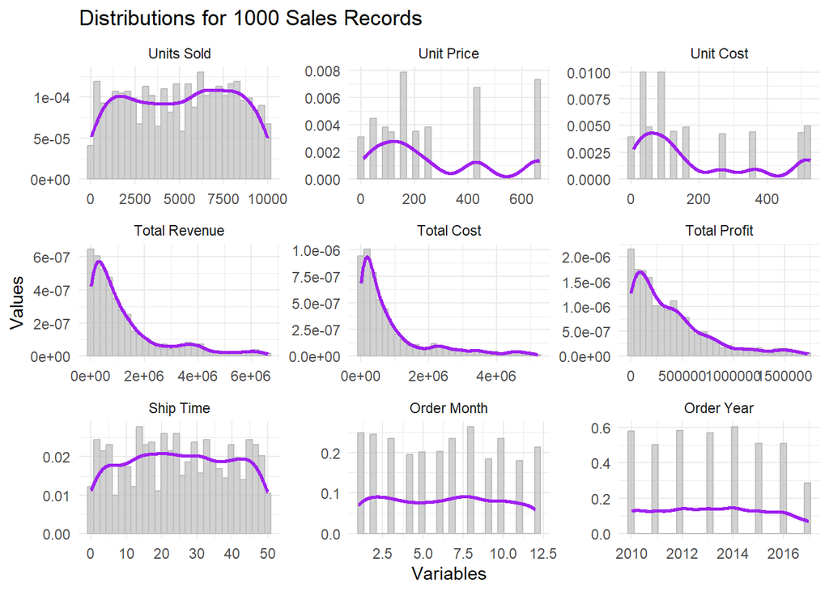

```r
# Create density plots for numeric columns
density_plot_function(df_1000, 'Distributions for 1000 Sales Records')
```

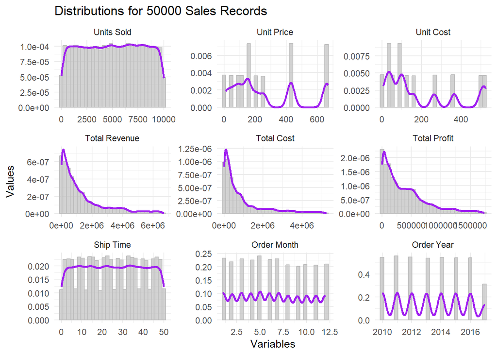

```r
density_plot_function(df_50000, 'Distributions for 50000 Sales Records')
```

`Total Revenue` vs. `Units Sold`: There was a strong positive association between the number of units sold and the total revenue earned by those sales, showing that as the number of units sold increases, so did the overall revenue. This was understandable given that income is directly proportional to the number of units sold multiplied by the unit price.

`Total Revenue` vs. `Unit Price`: There was no obvious linear relationship between total income and item unit pricing. While higher unit prices could lead to higher revenues, the quantity sold also played a role. Some lower-priced items might have higher sales quantities, resulting in equivalent income.

The scatter plots were similar for the small and large data.

```r
# A function to create scatter plots to visualize a grid:
# Units Sold vs Total Revenue
# Unit Price vs Total Revenue
# Total Cost vs Total Profit
#

plot_relationships <- function(df, title) {
  # Plot for Units Sold vs Total Revenue
  a1 <- ggplot(df, aes(x=units_sold, y=total_revenue)) +
    geom_point(alpha=0.5, color="blue") +
    labs(
        x = "Unit Sold",
        y = "Total Revenue") +
    theme_minimal()

  # Plot for Unit Price vs Total Revenue
  a2 <- ggplot(df, aes(x=unit_price, y=total_revenue)) +
    geom_point(alpha=0.5, color="blue") +
    labs(
        x = "Unit Price",
        y = "Total Revenue") +
    theme_minimal()

  # Plot for Total Cost vs Total Profit
  a3 <- ggplot(df, aes(x=total_cost, y=total_profit)) +
    geom_point(alpha=0.5, color="blue") +
    labs(
        x = "Total Cost",
        y = "Total Profit") +
    theme_minimal()

  # Arrange the plots in a grid
  grid.arrange(a1, a2, a3, ncol=3, top=title)
}
```

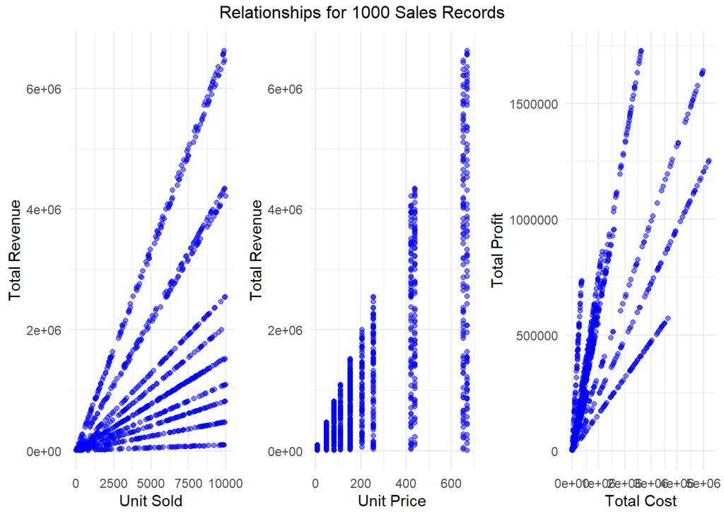

```r
# Scatter plots for numeric columns
plot_relationships(df_1000, 'Relationships for 1000 Sales Records')
```

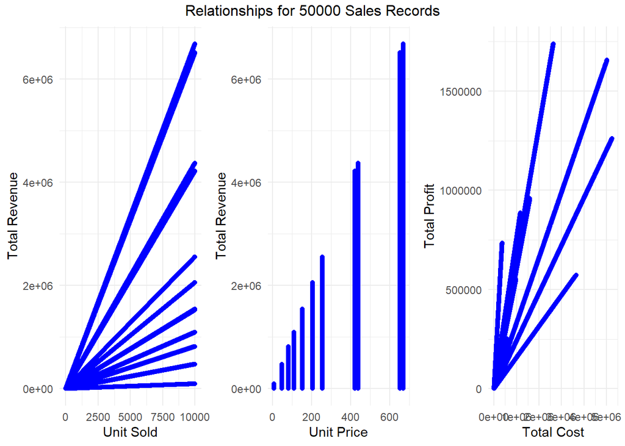

```r
plot_relationships(df_50000, 'Relationships for 50000 Sales Records')
```

`Total Profit` vs. `Units Sold`: The scatter plot demonstrated an expected positive linear relationship between the number of `Units Sold` and `Total Profit`.

The `Order Priority` hue offered further information about how different order priority were spread among sales records. It was worth noting that higher order priorities didn’t always equate to more units sold or bigger profitability.

The scatter plots were similar for the small and large data.

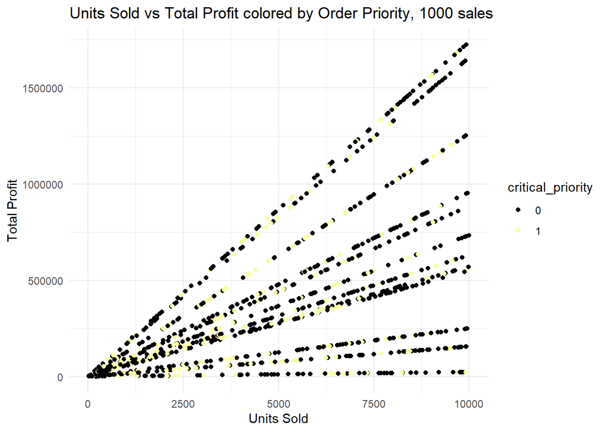

```r
# Scatter plot for Units Sold vs Total Profit colored by Order Priority
ggplot(df_1000, aes(x=units_sold, y=total_profit, color=critical_priority)) +
    geom_point() +
    scale_color_viridis_d(option = "inferno") +
    labs(
        x = "Units Sold",
        y = "Total Profit",
        title = 'Units Sold vs Total Profit colored by Order Priority, 1000 sales') +
    theme_minimal()
```

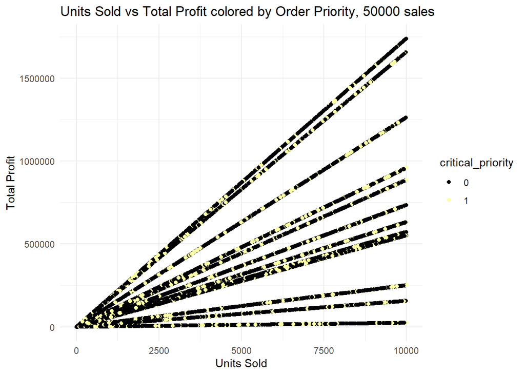

```r
ggplot(df_50000, aes(x=units_sold, y=total_profit, color=critical_priority)) +
    geom_point() +
    scale_color_viridis_d(option = "inferno") +
    labs(
        x = "Units Sold",
        y = "Total Profit",
        title = 'Units Sold vs Total Profit colored by Order Priority, 50000 sales') +
    theme_minimal()
```

### 2.3 Category variables

`Order Priority Count`: On the graph with the distribution of records based on order priority, the majority of orders had not a critical priority.

`Total Profit by Order Priority`: On the box plot with the distribution of `Total Profit` across different order priority, profits varied widely across priority, with the median profit appearing to be consistent.

`Units Sold by Order Priority`: There was no apparent trend demonstrating that a specific order priority regularly generated greater or lower sales. Although all priorities had a wide range of sales, the median sales appeared to be larger for non-critical priority.

The large data was more balanced in terms of dummy variables than small data.

```r
# A function to create 3 box plots that compare sales and order priority data:
# The number of orders by order priority.
# The total profit by order priority.
# The units sold by order priority.

priority_sales_function <- function(df, title) {

# Bar plot for 'Order Priority'
a2 <- ggplot(df, aes(x=critical_priority)) +
    geom_bar(fill=viridis(1)) +
            labs(
        x = "Order Priority",
        y = "Count",
        title = "'Count by Order Priority") +
    theme_minimal() + theme(legend.position = "none")


# Box plot for 'Total Profit' by 'Order Priority'
a4 <- ggplot(df, aes(x=critical_priority, y=total_profit, fill=critical_priority)) +
    geom_boxplot() +
    scale_fill_viridis_d() +
    ggtitle('Total Profit by Order Priority') +
              labs(
        x = "Order Priority",
        y = "Total Profit",
        title = "'Total Profit by Order Priority") +
    theme_minimal() +  theme(legend.position = "none")


a6 <- ggplot(df, aes(x=critical_priority, y=units_sold, fill=critical_priority)) +
    geom_boxplot() +
    scale_fill_viridis_d() +
        labs(
        x = "Order Priority",
        y = "Units Sold",
        title = "Units Sold by Order Priority") +
    theme_minimal() +  theme(legend.position = "none")


# Print the plots
grid.arrange(a2, a4, ncol=2, top=title)
grid.arrange(a6, ncol=1)
}
```

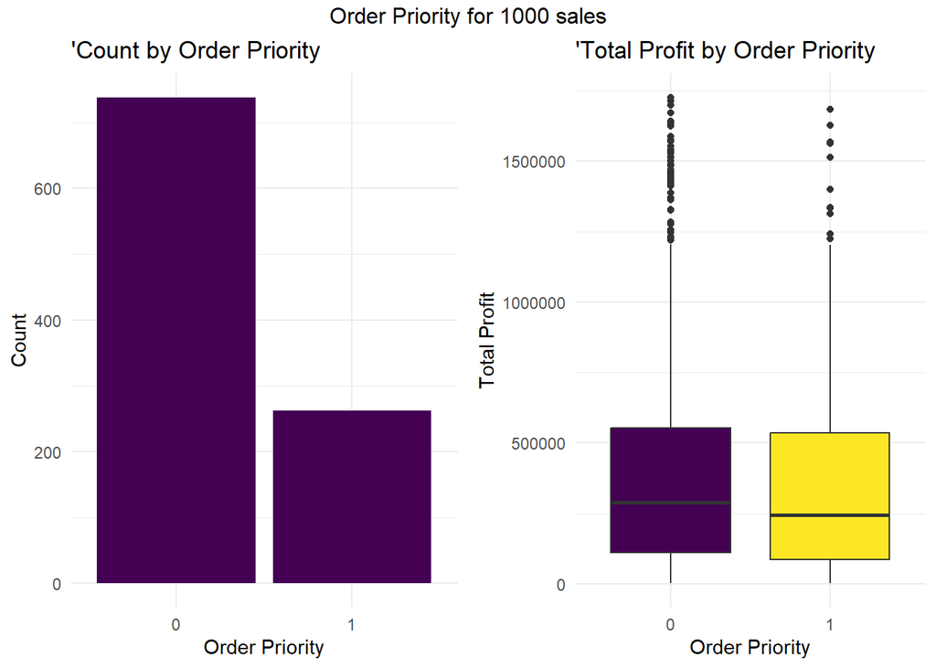

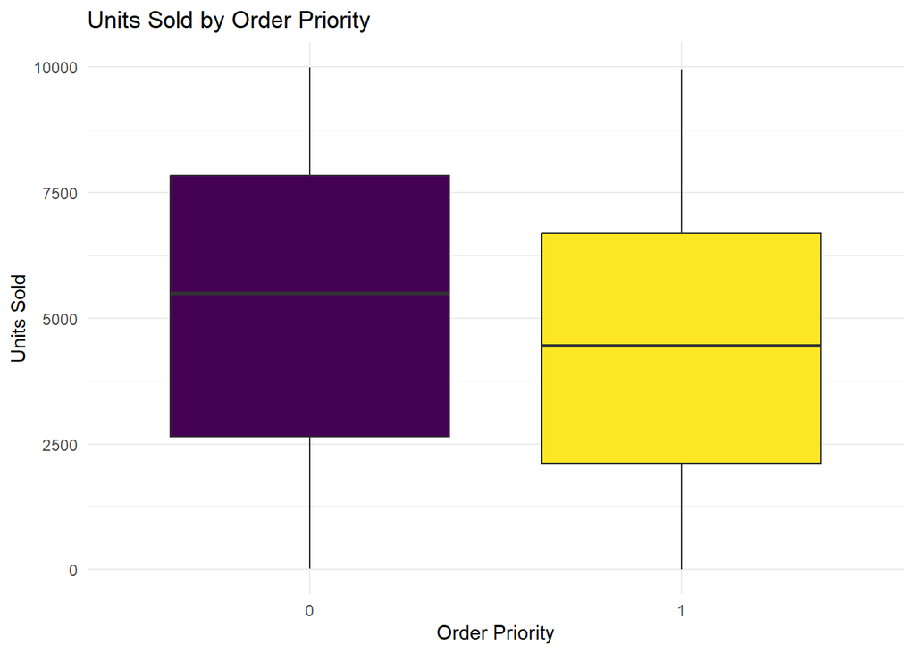

```r
# Box plots for sales channel, order priority
priority_sales_function(df_1000, "Order Priority for 1000 sales")
```

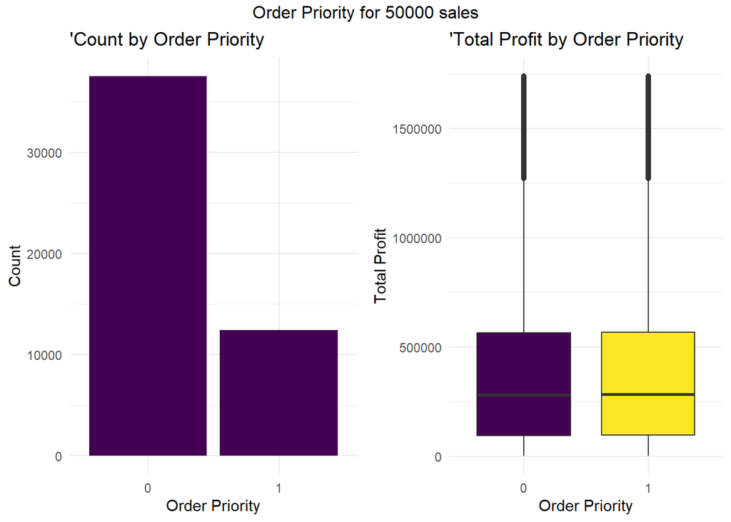

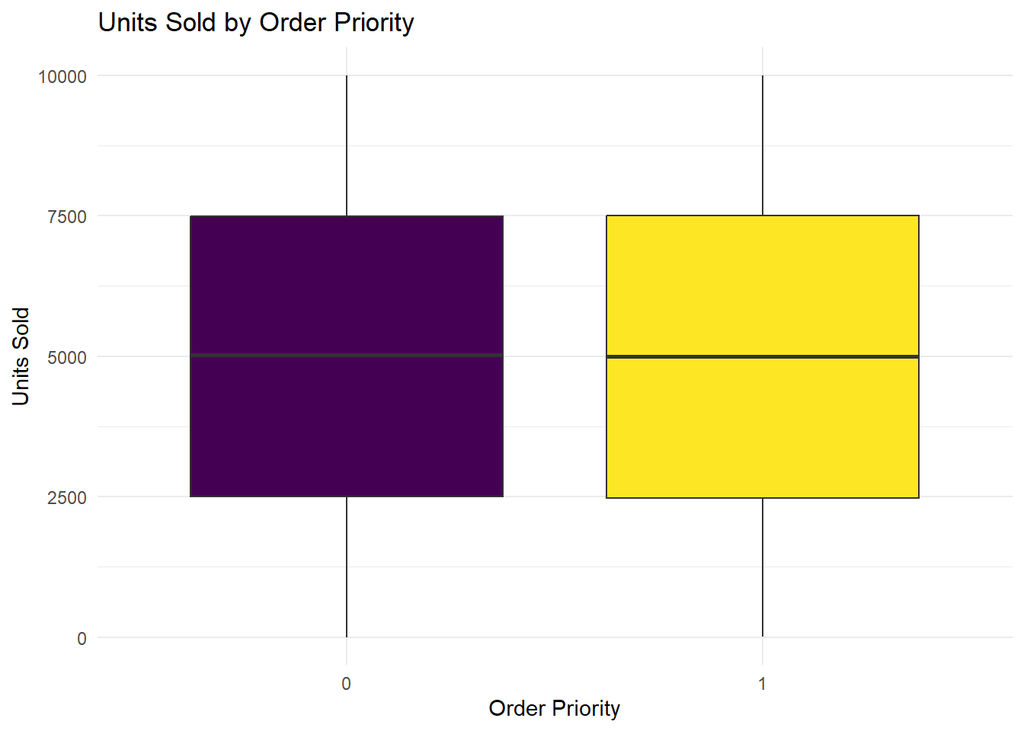

```r
priority_sales_function(df_50000, "Order Priority for 50000 sales")
```

Critical priority sales were distributed similarly across both online and offline sales channels, with non-critical sales being more common.

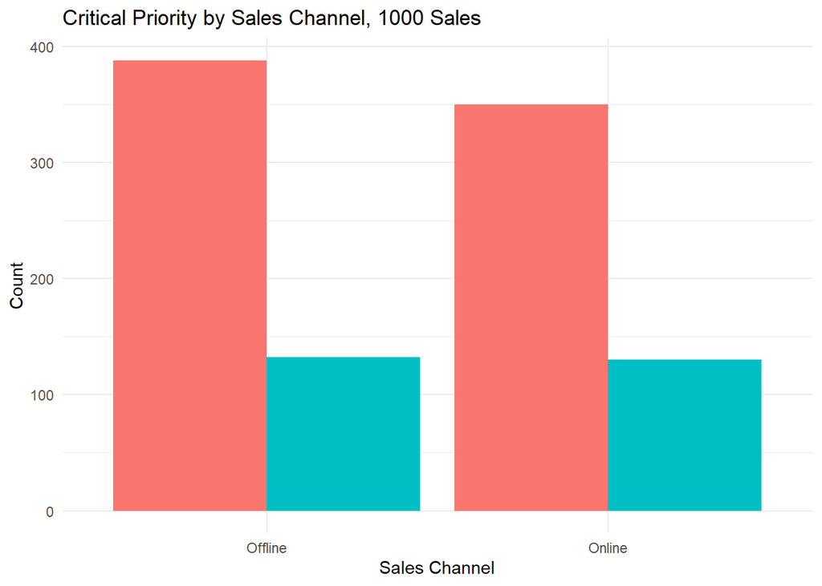

```r
# Distribution of Critical Priority by Sales Channel
ggplot(df_1000, aes(x = sales_channel, fill = critical_priority)) +
  geom_bar(position = "dodge") +
  labs(
    x = 'Sales Channel',
    y = 'Count',
    title = 'Critical Priority by Sales Channel, 1000 Sales') +
  theme_minimal() +  theme(legend.position = "none")
```

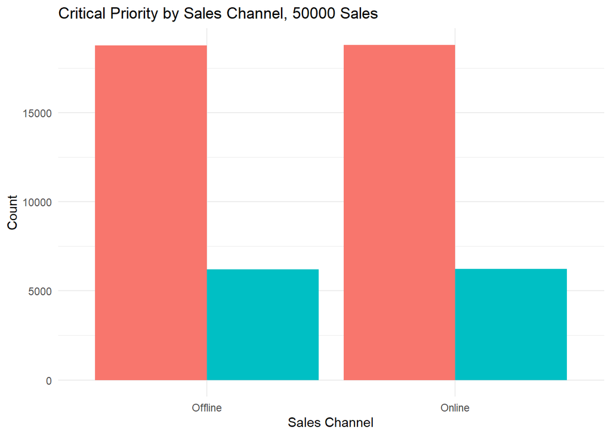

```r
ggplot(df_50000, aes(x = sales_channel, fill = critical_priority)) +
  geom_bar(position = "dodge") +
  labs(
    x = 'Sales Channel',
    y = 'Count',
    title = 'Critical Priority by Sales Channel, 50000 Sales') +
  theme_minimal() +  theme(legend.position = "none")
```

`Total Profit vs Region`: The median profit was reasonably consistent among regions, although each location had a large range of profits, as evidenced by the length of the boxes and whiskers.

`Units Sold by Region`: The median number of units sold was rather consistent among regions as shown on the box plot, similar to the profit distribution, however there was diversity within each zone.

All the plots for both data sets were almost the same except that median for units sold by region and total profit by region were more equal for a large data than for a small data.

```r
# A function to create a set of three box plots that compare sales data by region:
# The number of orders by region.
# The total profit by region.
# The units sold by region.

byregion_function <- function(df, title) {
  # Reordering the levels of 'Region' based on their counts
  df$region <- factor(df$region, levels = names(sort(table(df$region), decreasing = TRUE)))

# Bar plot for 'Region'
a1 <- ggplot(df, aes(x = region, fill = critical_priority)) +
  geom_bar(position = "dodge") +
      labs(
        x = "Region",
        y = "Count",
        title = "Critical Priority by Region") +
    theme_minimal() +
    theme(axis.text.x = element_text(angle = 45, hjust = 1), legend.position = "none")

# Box plot for 'Total Profit' by 'Region'
a2 <- ggplot(df, aes(x=region, y=total_profit, fill=region)) +
    geom_boxplot() +
    scale_fill_viridis_d() +
      labs(
        x = "Region",
        y = "Total Profit",
        title = "Total Profit by Region") +
    theme_minimal() +
    theme(axis.text.x = element_text(angle = 45, hjust = 1), legend.position = "none")

# Box plot for 'Units Sold' by 'Region'
a3 <- ggplot(df, aes(x=region, y=units_sold, fill=region)) +
    geom_boxplot() +
    scale_fill_viridis_d() +
        labs(
        x = "Region",
        y = "Units Sold",
        title = "Units Sold by Region") +
    theme_minimal() +
    theme(axis.text.x = element_text(angle = 45, hjust = 1), legend.position = "none")

grid.arrange(a1, ncol=1, top=title)
grid.arrange(a2, ncol=1)
grid.arrange(a3, ncol=1)

}
```

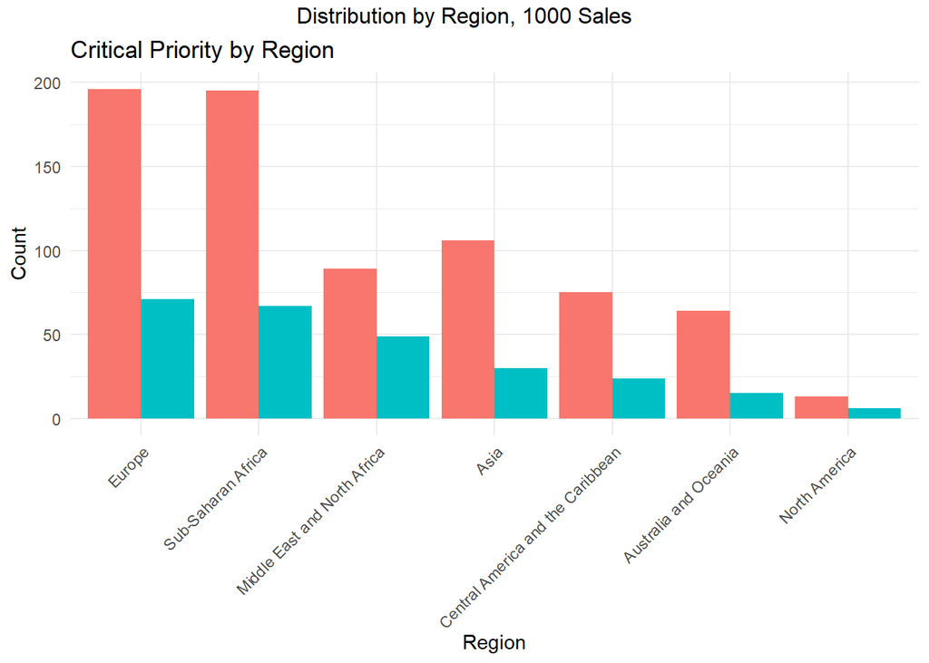

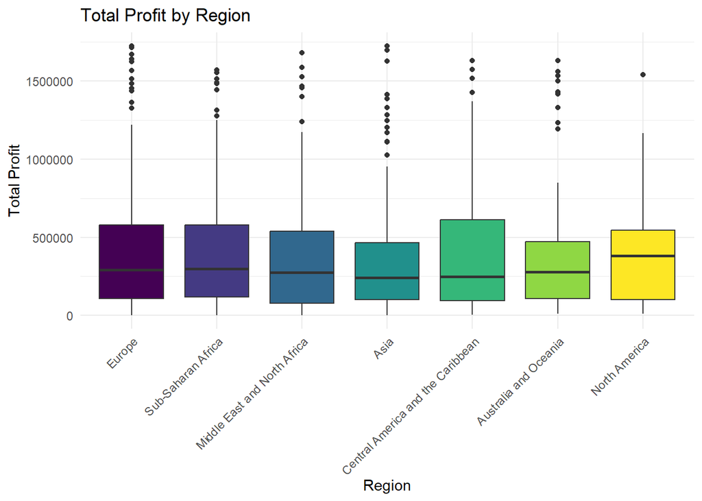

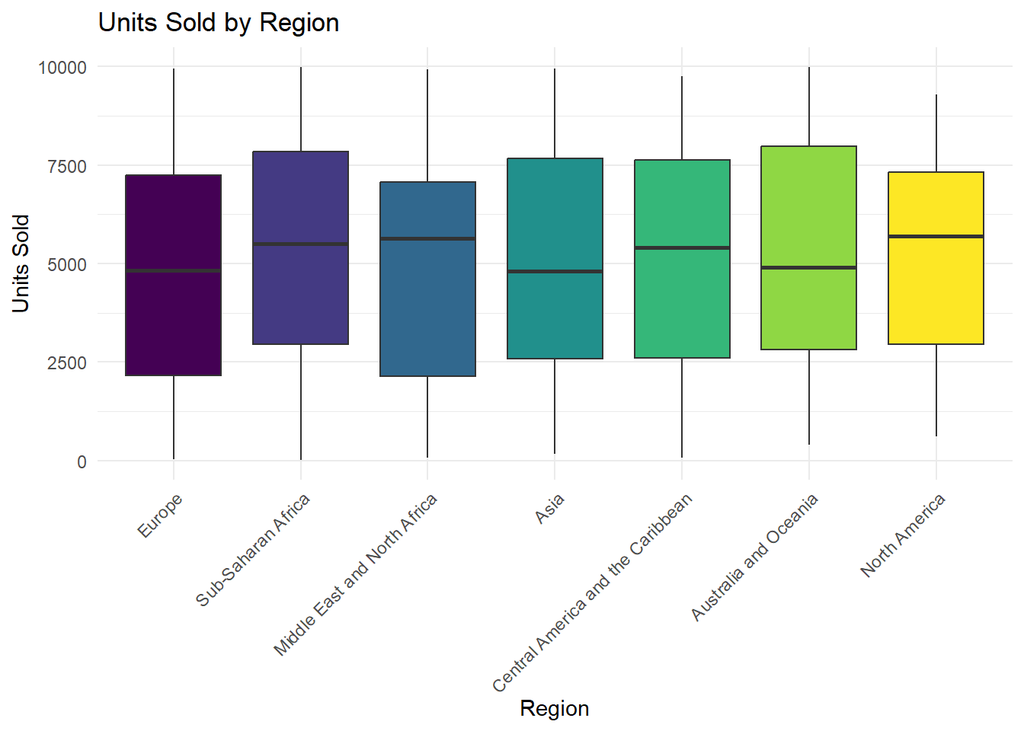

```r
# Boxplots for Region disctribution
byregion_function(df_1000, "Distribution by Region, 1000 Sales")
```

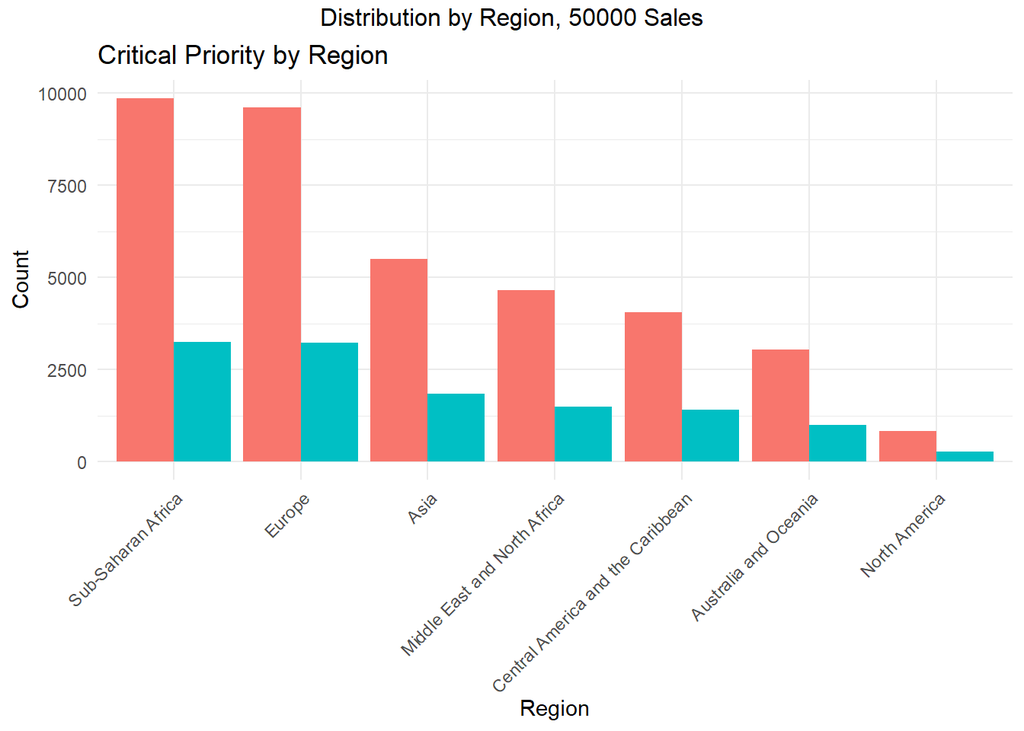

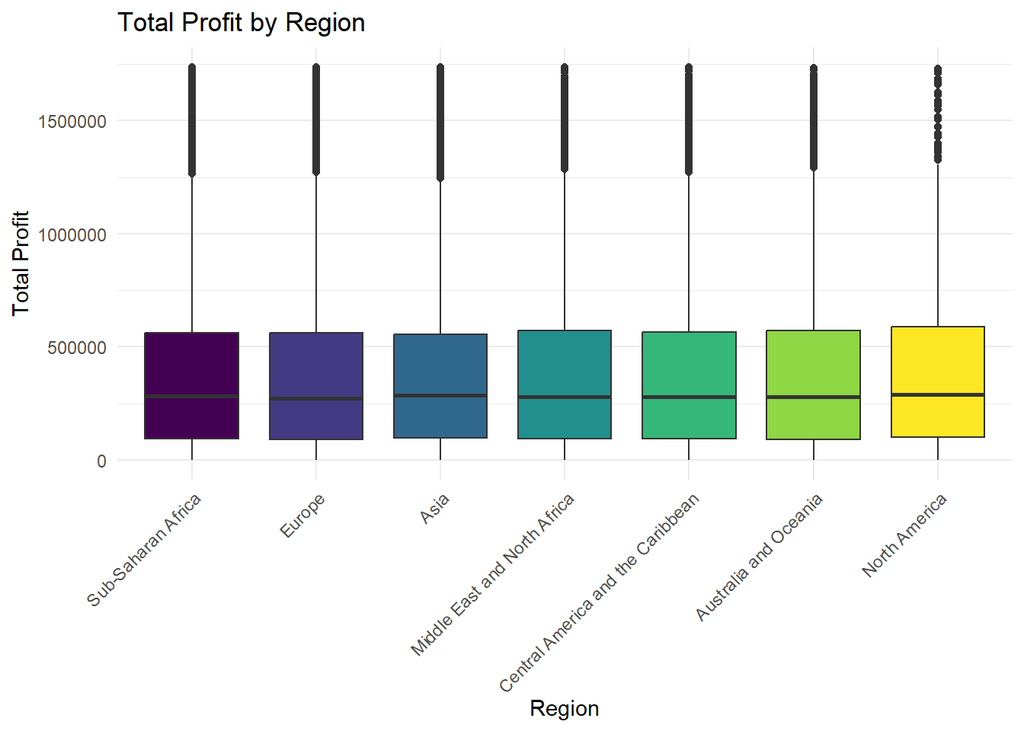

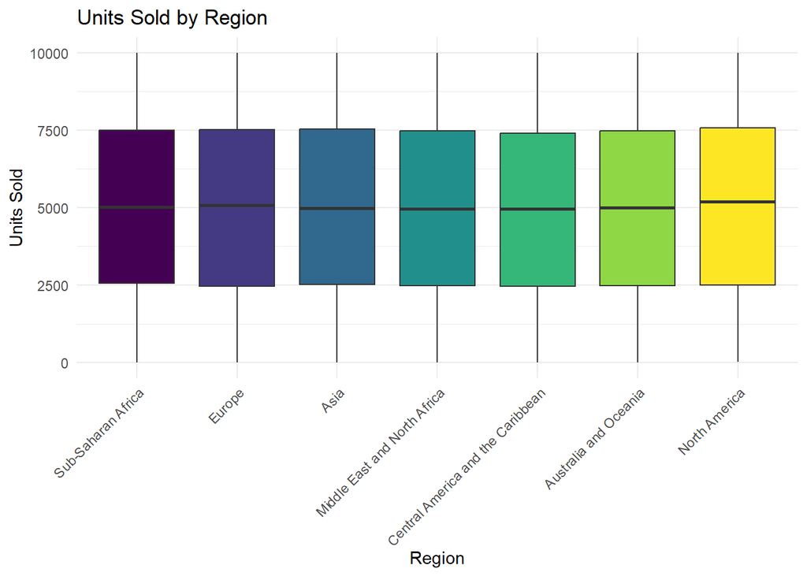

```r
byregion_function(df_50000, "Distribution by Region, 50000 Sales")
```

`Profitability by Item Type`: The distribution of `Total Profit` among different item types showed the variation in profit among item types. Some things, such as `Cosmetics` had larger median profits than others, such as `Vegetables`, which had lower median earnings.

`Units Sold by Item Type`: The distribution of `Units Sold` across different item kinds depicted that the number of units sold varied depending on the product. For example, `Baby Food` had a greater median unit sale, whereas ‘Cereal’ had a lower median.

```r
# A function to create a set of two plots to compare the distribution of total profit and units sold by item type:
# The total profit by item type.
# Tthe units sold by item type.

items_distribution <- function(df, title) {
  # Reordering the levels of 'Item Type' based on their counts
df$item_type <- factor(df$item_type, levels = names(sort(table(df$item_type), decreasing = TRUE)))

# Box plot for 'Total Profit' by 'Item Type'
a1 <- ggplot(df, aes(x=item_type, y=total_profit, fill=item_type)) +
    geom_boxplot() +
    scale_fill_viridis_d() +
        labs(
        x = "Item Type",
        y = "Total Profit",
        title = "Total Profit by Item Type") +
    theme_minimal()+
    theme(axis.text.x = element_text(angle = 45, hjust = 1), legend.position = "none")

# Box plot for 'Units Sold' by 'Item Type'
a2 <- ggplot(df, aes(x=item_type, y=units_sold, fill=item_type)) +
    geom_boxplot() +
    scale_fill_viridis_d() +
        labs(
        x = "Item Type",
        y = "Units Sold",
        title = "Units Sold by Item Type") +
    theme_minimal()+
    theme(axis.text.x = element_text(angle = 45, hjust = 1), legend.position = "none")

# Distribution of Critical Priority by Item Type
a3 <- ggplot(df, aes(x = item_type, fill = critical_priority)) +
  geom_bar(position = "dodge") +
  labs(
    x ="'Item Type",
    y = "Count",
    title = 'Critical Priority by Item Type') +
  theme_minimal() +
  theme(axis.text.x = element_text(angle = 45, hjust = 1))


# Print the plots
grid.arrange(a1, ncol=1, top=title)
grid.arrange(a2, ncol=1)
grid.arrange(a3, ncol=1)
}
```

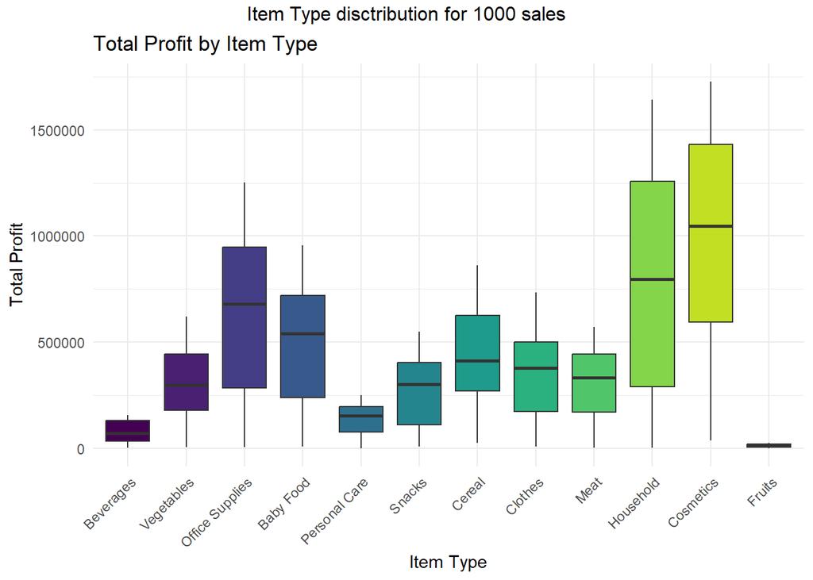

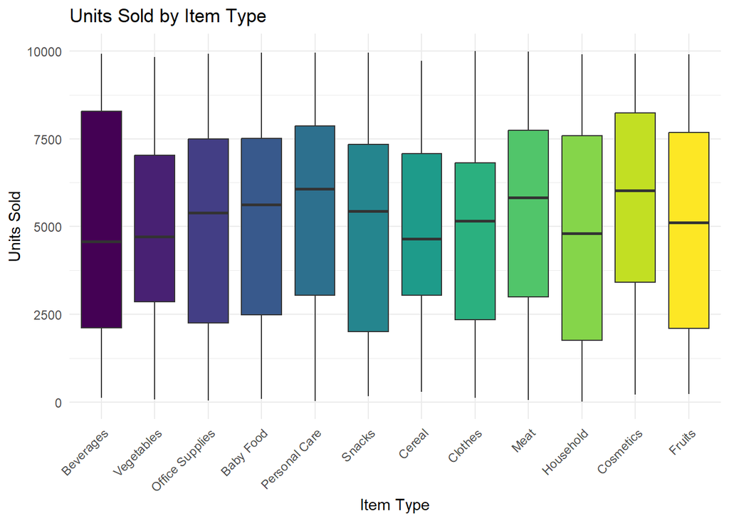

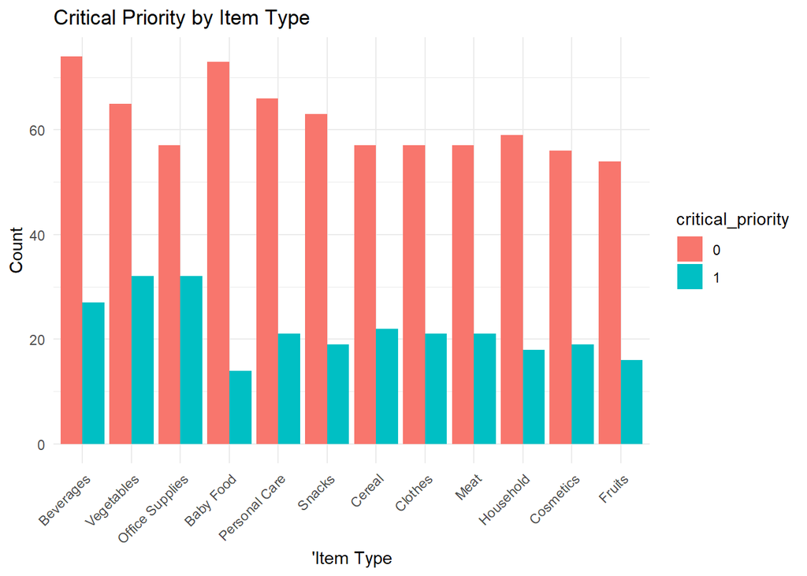

```r
# Boxplots for item distribution
items_distribution(df_1000, "Item Type disctribution for 1000 sales")
```

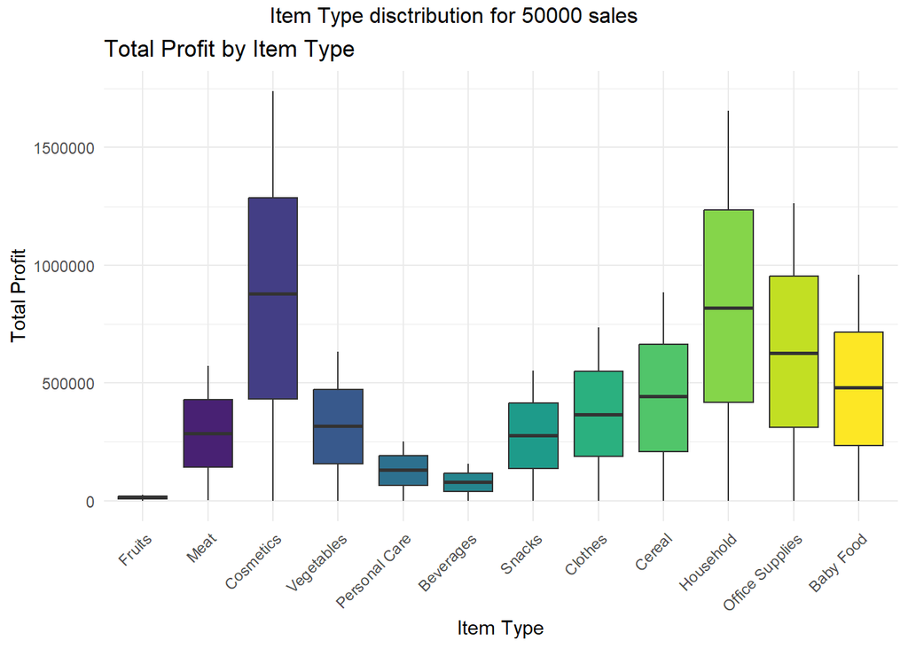

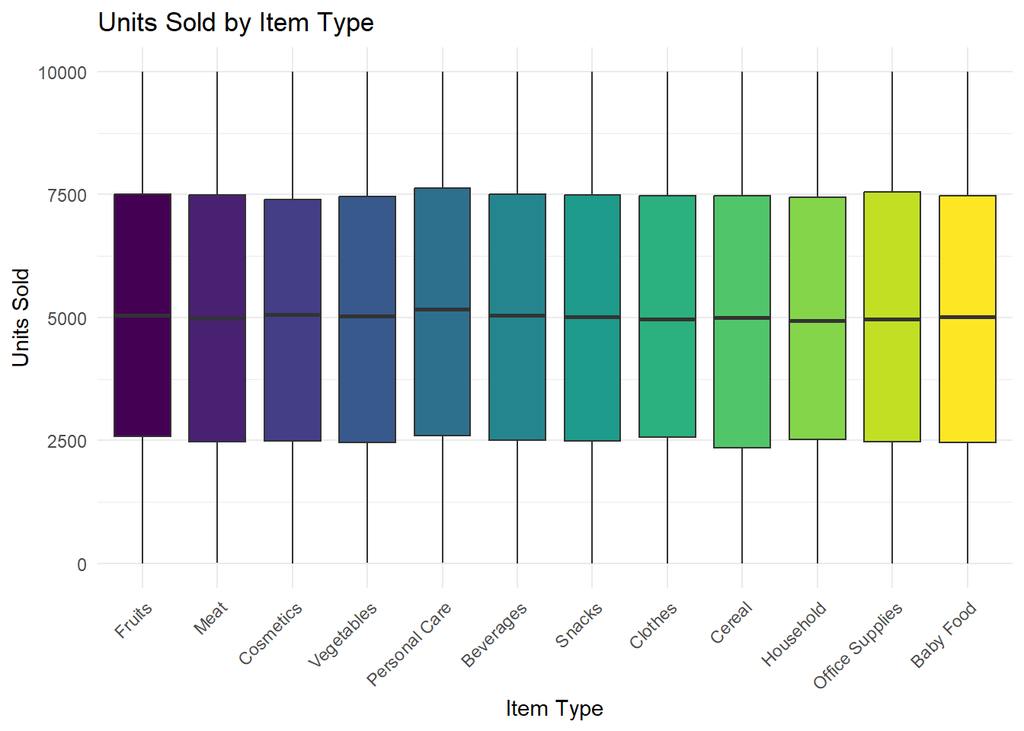

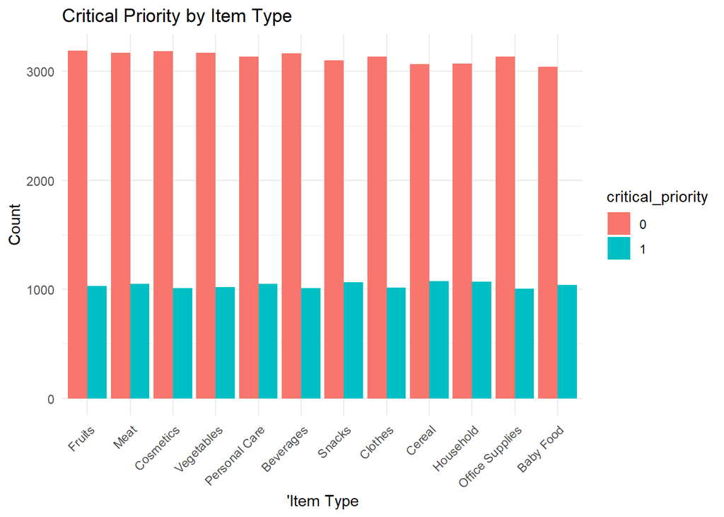

```r
items_distribution(df_50000, "Item Type disctribution for 50000 sales")
```

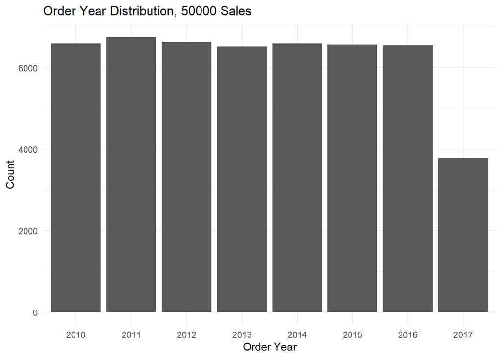

```r
# Order Year count

ggplot(df_50000, aes(x = as.factor(order_year))) +
  geom_bar() +
  labs(title = 'Order Year Distribution, 50000 Sales', x = 'Order Year', y = 'Count') +
  theme(text = element_text(size = 12),
        axis.text.x = element_text(angle = 45, hjust = 1),
        plot.title = element_text(hjust = 0.5, size = 15)) +
  theme_minimal()
```

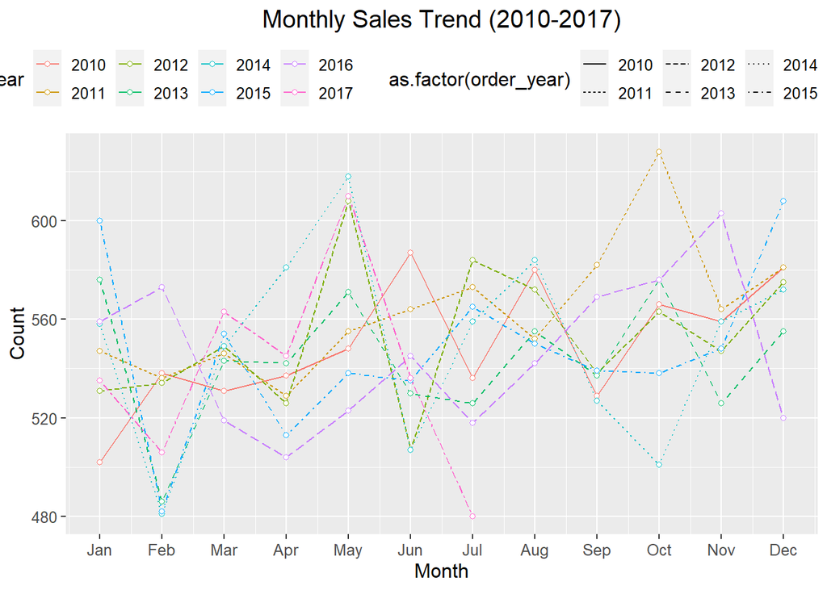

```r
# Aggregate data by order year and order month
sales <- df_50000 %>%
  group_by(order_year, order_month) %>%
  summarise(sales = n()) %>%
  ungroup()

# Monthly Sales Trend
ggplot(sales, aes(x = order_month, y = sales, group = order_year, color = as.factor(order_year))) +
  geom_line(aes(linetype = as.factor(order_year))) +
  geom_point(shape = 21, fill = "white") +
  scale_x_continuous(breaks = 1:12, labels = c('Jan', 'Feb', 'Mar', 'Apr', 'May', 'Jun', 'Jul', 'Aug', 'Sep', 'Oct', 'Nov', 'Dec')) +
  labs(title = 'Monthly Sales Trend (2010-2017)', x = 'Month', y = 'Count') +
  theme(text = element_text(size = 12),
        plot.title = element_text(hjust = 0.5, size = 15),
        legend.position = "top",
        legend.title = element_text(size = 12)) +
  guides(color = guide_legend(title = "Year"))
```

### 2.3 Correlation

The `Unit Price` and `Unit Cost` had a significant connection, which made logical given that cost and price were frequently associated. `Total Revenue`, `Total Cost` and `Total Profit` were likewise closely connected, which was to be expected given that they were generated from one another. `Units Sold` had a strong relationship with `Total Revenue`, `Total Cost`, and `Total Profit`. This made sense because the number of units sold had an immediate influence on revenue, cost, and profit.

`Region` and `Country` were be entirely dependent on one another for an obvious reason. As well as `Order Date` and `Shipping Date` that were naturally correlated, and additionally affected by the item type.

The correlation matrix for 1000 sales.

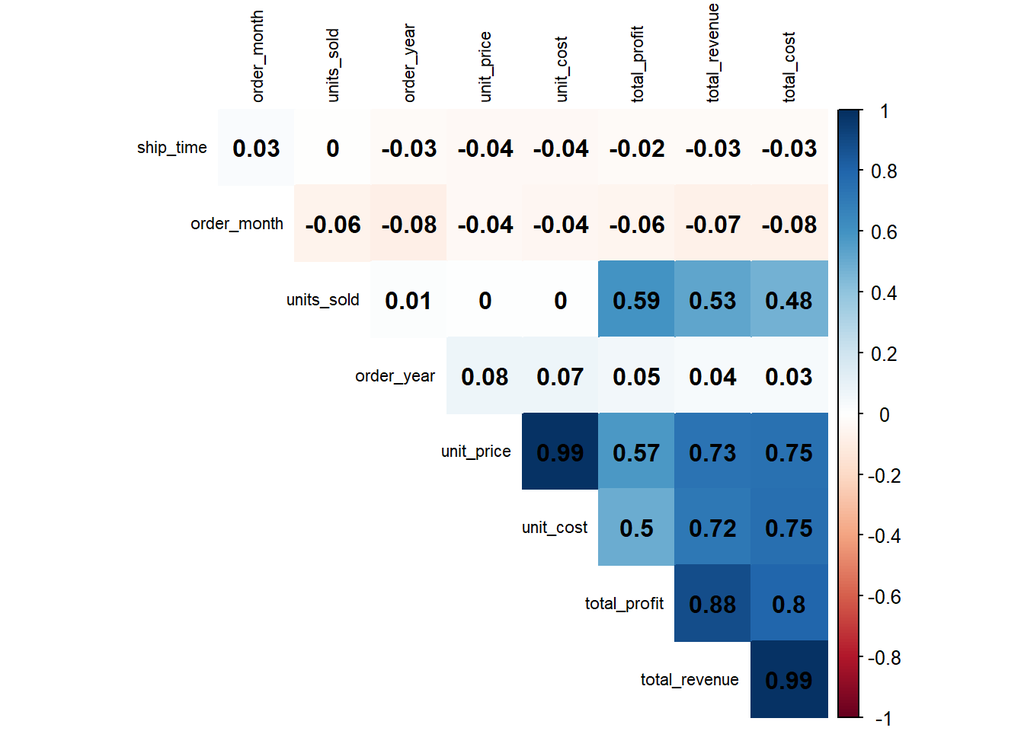

```r
rcore <- rcorr(as.matrix(df_1000 %>% dplyr::select(where(is.numeric))))
coeff <- rcore$r
corrplot(coeff, tl.cex = .7, tl.col="black", method = 'color', addCoef.col = "black",
         type="upper", order="hclust",
         diag=FALSE)
```

The correlation matrix for 50000 sales.

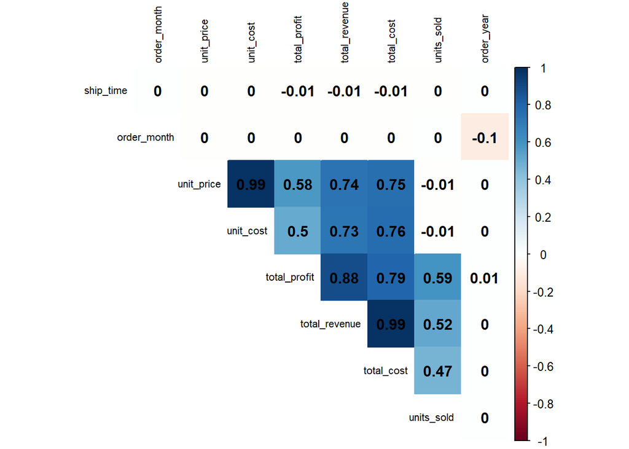

```r
rcore <- rcorr(as.matrix(df_50000 %>% dplyr::select(where(is.numeric))))
coeff <- rcore$r
corrplot(coeff, tl.cex = .7, tl.col="black", method = 'color', addCoef.col = "black",
         type="upper", order="hclust",
         diag=FALSE)
```

## 3 Data Transformation

Finally, we split our data into train (80%) and test (20%) datasets to evaluate model performance before we proceeded to prediction. The train data contained 800 sales, test data 200 sales for a small dataset.

Slightly different variations were used depending on each model’s needs.

The preprocessing technique and sample.split() were used for the simple Logistic Regression. The preprocessing consisted of encoding categorical variables (`region`, `item_type`, `sales_channel`) to make model’s coefficients more interpretable.

For the 1000 Sales Data, the response variable had a balance of 74% for `0` response and 26% for `1` response. This was the result of the distribution of the original column `Order Priority` where 4 values (C, H, M, L) had a part of ~26% each. For the further analysis, it could be an option to try balance the response variable.

With imbalanced data, most machine learning models predicted the majority class more efficiently than the minority class. To address this behavior, we utilized SMOTE() function the data in order to achieve higher accuracy rates between classes. The SMOTE function oversampled the minority class by using bootstrapping and k-nearest neighbor to synthetically create additional observations of that event. We tried to run models with imbalanced data and without.

```r
temp_1 <- df_1000


# Creating recipe to encode all categorical variables except for a target variable
preprocess_factors <- recipe(critical_priority ~ ., data = temp_1) %>%
  step_dummy(all_nominal(), -all_outcomes(), one_hot = FALSE)

# Fit the preprocessing technique
preprocess_factors_prep <- prep(preprocess_factors)


# Encode factor variables
temp_1_transformed <- bake(preprocess_factors_prep, new_data = temp_1)
temp_1_transformed <- temp_1_transformed  %>%
  mutate_at(vars(starts_with("item_type"), starts_with("region"), starts_with("sales_channel")), as.factor)

# random seed
set.seed(42)

# 80/20 split of the data set
sample <- sample.split(temp_1_transformed$critical_priority, SplitRatio = 0.8)
train_data  <- subset(temp_1_transformed, sample == TRUE)
test_data   <- subset(temp_1_transformed, sample == FALSE)

# Check dimenstions of train and test data
dim(train_data)
```

```
## [1] 800  28
```

```r
dim(test_data)
```

```
## [1] 200  28
```

```r
# Check class distribution of original, train, and test sets
round(prop.table(table(dplyr::select(temp_1_transformed, critical_priority), exclude = NULL)), 4) * 100
```

```
##
##    0    1
## 73.8 26.2
```

```r
round(prop.table(table(dplyr::select(train_data, critical_priority), exclude = NULL)), 4) * 100
```

```
##
##     0     1
## 73.75 26.25
```

```r
round(prop.table(table(dplyr::select(test_data, critical_priority), exclude = NULL)), 4) * 100
```

```
##
##  0  1
## 74 26
```

The response variable had a balance of 75% for `0` response and 25% for `1` response. This was the result of the distribution of the original column `Order Priority` where 4 values (C, H, M, L) had a part of ~25% each.

```r
temp_3 <- df_50000


# Creating recipe to encode all categorical variables except for a target variable
preprocess_factors <- recipe(critical_priority ~ ., data = temp_3) %>%
  step_dummy(all_nominal(), -all_outcomes(), one_hot = FALSE)

# Fit the preprocessing technique
preprocess_factors_prep <- prep(preprocess_factors)


# Encode factor variables
temp_3_transformed <- bake(preprocess_factors_prep, new_data = temp_3)
temp_3_transformed <- temp_3_transformed  %>%
  mutate_at(vars(starts_with("item_type"), starts_with("region"), starts_with("sales_channel")), as.factor)

# random seed
set.seed(42)

# 80/20 split of the data set
sample <- sample.split(temp_3_transformed$critical_priority, SplitRatio = 0.8)
train_data_large  <- subset(temp_3_transformed, sample == TRUE)
test_data_large   <- subset(temp_3_transformed, sample == FALSE)

# Check dimenstions of train and test data
dim(train_data_large)
```

```
## [1] 40000    28
```

```r
dim(test_data_large)
```

```
## [1] 10000    28
```

```r
# Check class distribution of original, train, and test sets
round(prop.table(table(dplyr::select(temp_3_transformed, critical_priority), exclude = NULL)), 4) * 100
```

```
##
##     0     1
## 75.11 24.89
```

```r
round(prop.table(table(dplyr::select(train_data_large, critical_priority), exclude = NULL)), 4) * 100
```

```
##
##     0     1
## 75.11 24.89
```

```r
round(prop.table(table(dplyr::select(test_data_large, critical_priority), exclude = NULL)), 4) * 100
```

```
##
##     0     1
## 75.11 24.89
```

The train and test data frame were transformed into vectors and the corresponding matrix (X, Y) for the k-fold cross-validation.The SMOTE() function was applied to the data in order to achieve higher accuracy rates between classes.

```r
temp_2 <- df_1000

# random seed
set.seed(42)

# 80/20 split of the data set
sample <- sample.split(temp_2$critical_priority, SplitRatio = 0.8)
df_train  <- subset(temp_2, sample == TRUE)
df_test   <- subset(temp_2, sample == FALSE)

# Fix imbalance
split_df <- as.data.frame(df_train)
split_df$critical_priority <- as.factor(split_df$critical_priority)
split_df <- SMOTE(critical_priority ~ ., split_df, perc.over = 100, perc.under=200)
split_df$critical_priority <- as.factor(split_df$critical_priority)

# Transform to vectors and the corresponding matrix
x_train <- model.matrix(critical_priority ~ ., data=split_df)[,-1]
y_train <- split_df[,"critical_priority"]

x_test <- model.matrix(critical_priority ~ ., data=df_test)[,-1]
y_test <- df_test[,"critical_priority"]
```

```r
temp_4 <- df_50000

# random seed
set.seed(42)


# 80/20 split of the data set
sample <- sample.split(temp_4$critical_priority, SplitRatio = 0.8)
df_train_large  <- subset(temp_4, sample == TRUE)
df_test_large   <- subset(temp_4, sample == FALSE)

# Fix imbalance
split_df_large <- as.data.frame(df_train_large)
split_df_large$critical_priority <- as.factor(split_df_large$critical_priority)
split_df_large  <- SMOTE(critical_priority ~ ., split_df_large, perc.over = 100, perc.under=200)
split_df_large$critical_priority <- as.factor(split_df_large$critical_priority)


# Transform to vectors and the corresponding matrix
x_train_large <- model.matrix(critical_priority ~ ., data=split_df_large)[,-1]
y_train_large <- split_df_large[,"critical_priority"]

x_test_large <- model.matrix(critical_priority ~ ., data=df_test_large)[,-1]
y_test_large <- df_test_large[,"critical_priority"]
```

For the Random Forest Model, the datasets without transformations were used. The SMOTE() function was applied to the data in order to achieve higher accuracy rates between classes.

```r
set.seed(42)

splitIndex <- sample.split(df_1000$critical_priority, SplitRatio = 0.8)
train_data_rf <-subset(df_1000, splitIndex == TRUE)
test_data_rf <- subset(df_1000, splitIndex == FALSE)

# Fix imbalance
split_rf <- as.data.frame(train_data_rf)
split_rf$critical_priority <- as.factor(split_rf$critical_priority)
split_rf <- SMOTE(critical_priority ~ ., split_rf, perc.over = 100, perc.under=200)
split_rf$critical_priority <- as.factor(split_rf$critical_priority)
```

```r
set.seed(42)

splitIndex <- sample.split(df_50000$critical_priority, SplitRatio = 0.8)
train_data_large_rf <-subset(df_50000, splitIndex == TRUE)
test_data_large_rf <- subset(df_50000, splitIndex == FALSE)

# Fix imbalance
split_rf_large <- as.data.frame(train_data_large_rf)
split_rf_large$critical_priority <- as.factor(split_rf_large$critical_priority)
split_rf_large <- SMOTE(critical_priority ~ ., split_rf_large, perc.over = 100, perc.under=200)
split_rf_large$critical_priority <- as.factor(split_rf_large$critical_priority)
```

## 4 Models

### 4.1 Logistic regression - 1000 Sales

As the first step, we built the generalized linear model based on the transformed training dataset with categorical variables transformed to dummy variables. The variables `total_profit`, `total_cost`, `total_revenue` were dropped as they are connected with each other and derived from `unis_sold` and `units_cost` variables. Variables `item_type_Vegetables`, `item_type_Snacks` were removed as the model ran error when predicting the probabilities, the rank of the data matrix was at least equal to the number of parameters, it was not. Since our dependent variable takes only two values (0 and 1), we used logistic regression. To do so, the function `glm()` with `family=binomial` was used. A positive coefficient meant that as the predictor variable grew, so did the log odds of the outcome occurring, increasing the likelihood of the outcome. A negative coefficient implied the inverse.

```r
set.seed(42)
# Build logistic regression model
log_model <- glm(critical_priority ~ . -total_profit - total_revenue - total_cost - item_type_Vegetables - item_type_Snacks, data = train_data, binomial(link = "logit"), control = list(maxit = 1000))

summ(log_model)
```

| Observations | 800 |
| --- | --- |
| Dependent variable | critical_priority |
| Type | Generalized linear model |
| Family | binomial |
| Link | logit |

| χ²(22) | 40.59 |
| --- | --- |
| Pseudo-R² (Cragg-Uhler) | 0.07 |
| Pseudo-R² (McFadden) | 0.04 |
| AIC | 926.46 |
| BIC | 1034.20 |

|  | Est. | S.E. | z val. | p |
| --- | --- | --- | --- | --- |
| (Intercept) | 66.65 | 78.95 | 0.84 | 0.40 |
| units_sold | -0.00 | 0.00 | -3.24 | 0.00 |
| unit_price | 0.06 | 0.04 | 1.78 | 0.08 |
| unit_cost | -0.11 | 0.05 | -1.99 | 0.05 |
| ship_time | -0.00 | 0.01 | -0.45 | 0.65 |
| order_month | -0.04 | 0.02 | -1.72 | 0.09 |
| order_year | -0.03 | 0.04 | -0.84 | 0.40 |
| region_Australia.and.Oceania1 | -0.21 | 0.41 | -0.51 | 0.61 |
| region_Central.America.and.the.Caribbean1 | -0.05 | 0.37 | -0.15 | 0.88 |
| region_Europe1 | 0.19 | 0.28 | 0.67 | 0.50 |
| region_Middle.East.and.North.Africa1 | 0.73 | 0.31 | 2.36 | 0.02 |
| region_North.America1 | 0.80 | 0.61 | 1.30 | 0.19 |
| region_Sub.Saharan.Africa1 | 0.24 | 0.28 | 0.86 | 0.39 |
| item_type_Beverages1 | -0.28 | 0.71 | -0.40 | 0.69 |
| item_type_Cereal1 | -0.79 | 0.64 | -1.24 | 0.22 |
| item_type_Clothes1 | -3.74 | 1.62 | -2.31 | 0.02 |
| item_type_Cosmetics1 | 0.14 | 1.25 | 0.11 | 0.91 |
| item_type_Fruits1 | -0.54 | 0.82 | -0.65 | 0.52 |
| item_type_Household1 | 11.42 | 4.44 | 2.57 | 0.01 |
| item_type_Meat1 | 12.21 | 5.38 | 2.27 | 0.02 |
| item_type_Office.Supplies1 | 15.78 | 6.14 | 2.57 | 0.01 |
| item_type_Personal.Care1 | 0.30 | 0.74 | 0.40 | 0.69 |
| sales_channel_Online1 | 0.07 | 0.17 | 0.43 | 0.67 |

Standard errors: MLE

The Akaike information criterion (`AIC`) was `926.46` which could be high, there was a need to compare with other models.

The `accuracy` of the model was 71.5%. Based on the confusion matrix, the model didn’t perform well in predicting critical priority as it was shown by the precision and recall values for class 1 (`Sensitivity` was 5.8%). `F1 score` of `0.095` combined the precision and recall scores of a model (our model was 9.5% accurate in predicting positive cases and 90.5% inaccurate in predicting negative cases).

The `null deviance` of `921.05` defined how well the target variable could be predicted by a model with only an intercept term.

The `residual deviance` of `880.46` defined how well the target variable can be predicted by our current model that we fit with predictor variables mentioned above. The lower the value, the better the model could predict the value of the response variable.

```r
# Predict using test data
log_model_prob <- predict(log_model, newdata = test_data, type = "response")
log_model_pred <- ifelse(log_model_prob  > 0.5, 1, 0)

# Evaluate the Logistic Regression model
conf_matrix_1 <- confusionMatrix(factor(log_model_pred), factor(test_data$critical_priority), "1")


results <- tibble(Model = "Model #1 - Log Regression 1000 Sales", Accuracy=conf_matrix_1$overall[1],
                  "Classification error rate" = 1 - conf_matrix_1$overall[1],
                  F1 = conf_matrix_1$byClass[7],
                  Deviance= log_model$deviance,
                  R2 = 1 - log_model$deviance / log_model$null.deviance,
                  Sensitivity = conf_matrix_1$byClass["Sensitivity"],
                  Specificity = conf_matrix_1$byClass["Specificity"],
                  Precision =  conf_matrix_1$byClass["Precision"],
                  AIC= log_model$aic,
                  ROC = auc(roc(test_data$critical_priority, log_model_pred)))

conf_matrix_1
```

```
## Confusion Matrix and Statistics
##
##           Reference
## Prediction   0   1
##          0 140  49
##          1   8   3
##
##                Accuracy : 0.715
##                  95% CI : (0.6471, 0.7764)
##     No Information Rate : 0.74
##     P-Value [Acc > NIR] : 0.8131
##
##                   Kappa : 0.0049
##
##  Mcnemar's Test P-Value : 1.17e-07
##
##             Sensitivity : 0.05769
##             Specificity : 0.94595
##          Pos Pred Value : 0.27273
##          Neg Pred Value : 0.74074
##              Prevalence : 0.26000
##          Detection Rate : 0.01500
##    Detection Prevalence : 0.05500
##       Balanced Accuracy : 0.50182
##
##        'Positive' Class : 1
##
```

The feature importance plot below showed units sold and item type household, fruits, cosmetics had the largest positive influence, indicating that sales from these items were more likely to be prioritized. Item type beverages, on the other hand, had the largest negative influence, indicating that sales from these categories were less likely to be a major priority.

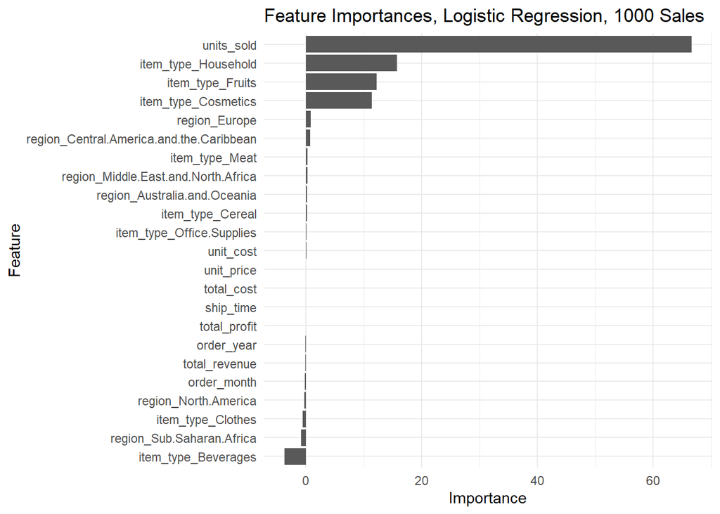

```r
# Get col names without target and coeff from model
feature_names <- colnames(train_data)
feature_names <- feature_names[ !feature_names == 'critical_priority']
coefficients <- log_model$coefficients

# Sort coeff in desc order
sort_coef <- order(abs(coefficients), decreasing = TRUE)

# Create the plot
ggplot(data.frame(Feature = feature_names[sort_coef], Coefficient = coefficients[sort_coef]), aes(x = Coefficient, y = reorder(Feature, Coefficient))) +
  geom_col() +
  labs(title = "Feature Importances, Logistic Regression, 1000 Sales", x = "Importance", y = "Feature") +
  theme_minimal()
```

We tried to fix the imbalance in the target variable using SMOTE() function and train the logistic model again (without excluding item_type_Vegetables and item_type_Snacks variables). The result of SMOTE() was a training dataset with 840 observations, where the target variable was balanced (50% for class 1 and 50% for class 0). F1 score was `0.37` (our model 37% was accurate in predicting positive cases).

The accuracy became lower `56%`. The sensitivity for class 1 now 50%, this case was much better comparing to the data with imbalance where the sensitivity was less than 6%. We kept these results for the further comparison.

```r
set.seed(42) # for repet results
trainSplit <- as.data.frame(train_data)
trainSplit$critical_priority <- as.factor(trainSplit$critical_priority)
trainSplit <- SMOTE(critical_priority ~ ., trainSplit, perc.over = 100, perc.under=200)
trainSplit$critical_priority <- as.factor(trainSplit$critical_priority)

prop.table(table(trainSplit$critical_priority))
```

```
##
##   0   1
## 0.5 0.5
```

```r
# Build logistic regression model
log_model <- glm(critical_priority ~ . -total_profit - total_revenue - total_cost, data = trainSplit, binomial(link = "logit"), control = list(maxit = 1000))

# Predict using test data
log_model_prob <- predict(log_model, newdata = test_data, type = "response")
log_model_pred <- ifelse(log_model_prob  > 0.5, 1, 0)

# Evaluate the Logistic Regression model
conf_matrix_1 <- confusionMatrix(factor(log_model_pred), factor(test_data$critical_priority), "1")


results <- tibble(Model = "Model #1 - Log Regression 1000 Sales", Accuracy=conf_matrix_1$overall[1],
                  "Classification error rate" = 1 - conf_matrix_1$overall[1],
                  F1 = conf_matrix_1$byClass[7],
                  Deviance= log_model$deviance,
                  R2 = 1 - log_model$deviance / log_model$null.deviance,
                  Sensitivity = conf_matrix_1$byClass["Sensitivity"],
                  Specificity = conf_matrix_1$byClass["Specificity"],
                  Precision =  conf_matrix_1$byClass["Precision"],
                  AIC= log_model$aic,
                  ROC = auc(roc(test_data$critical_priority, log_model_pred)))

conf_matrix_1
```

```
## Confusion Matrix and Statistics
##
##           Reference
## Prediction  0  1
##          0 87 26
##          1 61 26
##
##                Accuracy : 0.565
##                  95% CI : (0.4933, 0.6348)
##     No Information Rate : 0.74
##     P-Value [Acc > NIR] : 1.0000000
##
##                   Kappa : 0.0721
##
##  Mcnemar's Test P-Value : 0.0002672
##
##             Sensitivity : 0.5000
##             Specificity : 0.5878
##          Pos Pred Value : 0.2989
##          Neg Pred Value : 0.7699
##              Prevalence : 0.2600
##          Detection Rate : 0.1300
##    Detection Prevalence : 0.4350
##       Balanced Accuracy : 0.5439
##
##        'Positive' Class : 1
##
```

#### Assumptions

The linear link between the independent variables and the logit transformation of the response variable was required by the Logistic regression model. The visualization below showed some of the linearity between independent variables and the log-odds of the target.

```r
probabilities <- predict(log_model, type = "response")
predicted.classes <- ifelse(probabilities > 0.5, "pos", "neg")
head(predicted.classes)
```

```
##   432   458   298   516   778   421
## "pos" "pos" "neg" "pos" "neg" "neg"
```

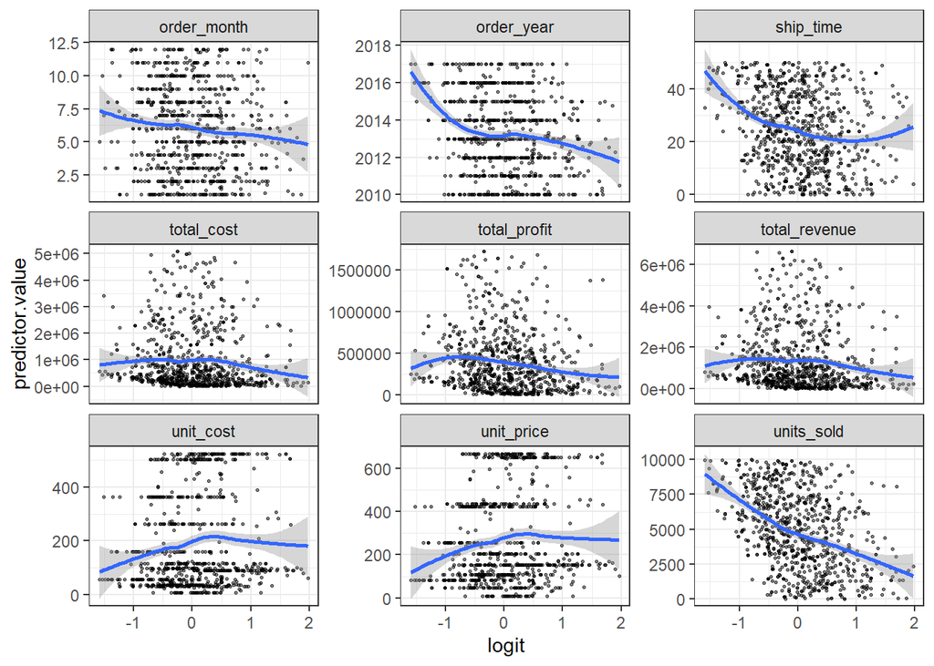

```r
#Only numeric predictors
data <- trainSplit %>%
  dplyr::select_if(is.numeric)
predictors <- colnames(data)

# Bind the logit and tidying the data for plot
data <- data %>%
  mutate(logit = log(probabilities/(1-probabilities))) %>%
  gather(key = "predictors", value = "predictor.value", -logit)

#Scatter plot
ggplot(data, aes(logit, predictor.value))+
  geom_point(size = 0.5, alpha = 0.5) +
  geom_smooth(method = "loess") +
  theme_bw() +
  facet_wrap(~predictors, scales = "free_y")
```

Also, observations had to be independent of each other. As this is a randomly created dataset, we could assume that each sale record was independent.

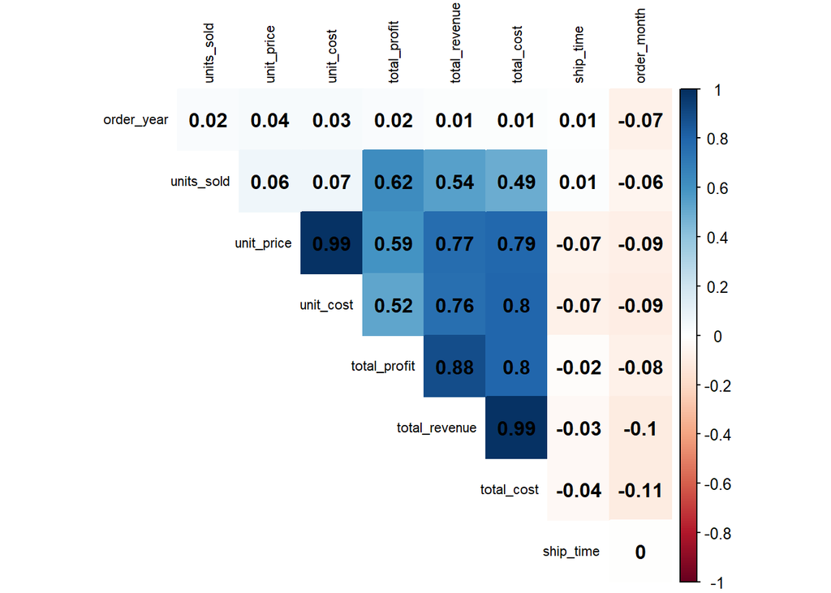

```r
rcore <- rcorr(as.matrix(trainSplit %>% dplyr::select(where(is.numeric))))
coeff <- rcore$r
corrplot(coeff, tl.cex = .7, tl.col="black", method = 'color', addCoef.col = "black",
         type="upper", order="hclust",
         diag=FALSE)
```

### 4.2 Logistic regression - 50000 Sales

The generalized linear model was built based on the transformed training dataset with categorical variables transformed to dummy variables. The variables `total_profit`, `total_cost`, `total_revenue` were dropped as in the previous model. The same glm() function was used to build the model.

A positive coefficient meant that as the predictor variable grew, so did the log odds of the outcome occurring, increasing the likelihood of the outcome. A negative coefficient implied the inverse. The data was balanced to better predict class 1.

The result of SMOTE() was a dataset with 39828 observations, where the target variable was balanced (50% for class 1 and 50% for class 0).

```r
set.seed(42) # for repet results
trainSplit_large <- as.data.frame(train_data_large)
trainSplit_large$critical_priority <- as.factor(trainSplit_large$critical_priority)
trainSplit_large <- SMOTE(critical_priority ~ ., trainSplit_large, perc.over = 100, perc.under=200)
trainSplit_large$critical_priority <- as.factor(trainSplit_large$critical_priority)

prop.table(table(trainSplit_large$critical_priority))
```

```
##
##   0   1
## 0.5 0.5
```

```r
set.seed(42)
# Build logistic regression model
log_model_large <- glm(critical_priority ~ . -total_profit - total_revenue - total_cost , data = trainSplit_large, binomial(link = "logit"), control = glm.control(maxit = 1000))

summ(log_model_large)
```

| Observations | 39828 |
| --- | --- |
| Dependent variable | critical_priority |
| Type | Generalized linear model |
| Family | binomial |
| Link | logit |

| χ²(24) | 170.72 |
| --- | --- |
| Pseudo-R² (Cragg-Uhler) | 0.01 |
| Pseudo-R² (McFadden) | 0.00 |
| AIC | 55092.61 |
| BIC | 55307.42 |

|  | Est. | S.E. | z val. | p |
| --- | --- | --- | --- | --- |
| (Intercept) | 5.82 | 9.35 | 0.62 | 0.53 |
| units_sold | -0.00 | 0.00 | -2.57 | 0.01 |
| unit_price | -0.00 | 0.00 | -2.14 | 0.03 |
| unit_cost | 0.00 | 0.00 | 1.73 | 0.08 |
| ship_time | -0.00 | 0.00 | -1.49 | 0.14 |
| order_month | 0.00 | 0.00 | 0.60 | 0.55 |
| order_year | -0.00 | 0.00 | -0.63 | 0.53 |
| region_Australia.and.Oceania1 | 0.20 | 0.04 | 4.95 | 0.00 |
| region_Central.America.and.the.Caribbean1 | 0.21 | 0.04 | 5.97 | 0.00 |
| region_Europe1 | 0.13 | 0.03 | 4.76 | 0.00 |
| region_Middle.East.and.North.Africa1 | 0.15 | 0.03 | 4.45 | 0.00 |
| region_North.America1 | 0.08 | 0.07 | 1.17 | 0.24 |
| region_Sub.Saharan.Africa1 | 0.10 | 0.03 | 3.62 | 0.00 |
| item_type_Beverages1 | -0.06 | 0.05 | -1.14 | 0.26 |
| item_type_Cereal1 | 0.21 | 0.04 | 4.79 | 0.00 |
| item_type_Clothes1 | 0.02 | 0.05 | 0.39 | 0.70 |
| item_type_Cosmetics1 | 0.16 | 0.06 | 2.58 | 0.01 |
| item_type_Fruits1 | -0.20 | 0.06 | -3.49 | 0.00 |
| item_type_Household1 | 0.24 | 0.06 | 3.78 | 0.00 |
| item_type_Meat1 | 0.01 | 0.06 | 0.19 | 0.85 |
| item_type_Office.Supplies1 | 0.18 | 0.07 | 2.75 | 0.01 |
| item_type_Personal.Care1 | 0.12 | 0.05 | 2.42 | 0.02 |
| item_type_Snacks1 | 0.13 | 0.04 | 3.10 | 0.00 |
| item_type_Vegetables1 | 0.19 | 0.04 | 4.49 | 0.00 |
| sales_channel_Online1 | 0.01 | 0.02 | 0.38 | 0.70 |

Standard errors: MLE

```r
# Build logistic regression model
#log_model_large <- glm(critical_priority ~ . -total_profit - total_revenue - total_cost - item_type_Vegetables - item_type_Snacks, data #= train_data_large, binomial(link = "logit"), control = glm.control(maxit = 1000))

#summ(log_model_large)
```

The Akaike information criterion (`AIC`) was `55092.61` which could be high, there was a need to compare with other models.

The `accuracy` of the model was 52%, lower than for the 1000 sales. The Logistic Regression model predicted 47% of the class 1. The model predicted the target, this couldn’t happen with imbalanced data. `F1 score` of `0.33` combined the precision and recall scores of a model (our model was 33% accurate in predicting positive cases and 67% inaccurate in predicting negative cases).

`AUC for the ROC curve` was `0.5`, it ranked a random positive example higher than a random negative example 50% of the time.

The `null deviance` of `55213.33` defined how well the target variable could be predicted by a model with only an intercept term.

The `residual deviance` of `55042.615` showed that our model couldn’t predict well the response variable.

```r
# Predict using test data
log_model_prob_large <- predict(log_model_large, newdata = test_data_large, type = "response")
log_model_pred_large <- ifelse(log_model_prob_large  > 0.5, 1, 0)

# Evaluate the Logistic Regression model
conf_matrix_2 <- confusionMatrix(factor(log_model_pred_large), factor(test_data_large$critical_priority), "1")


results <- rbind(results, tibble(Model = "Model #2 - Log Regression 50000 Sales", Accuracy=conf_matrix_2$overall[1],
                  "Classification error rate" = 1 - conf_matrix_2$overall[1],
                  F1 = conf_matrix_2$byClass[7],
                  Deviance= log_model_large$deviance,
                  R2 = 1 - log_model_large$deviance / log_model_large$null.deviance,
                  Sensitivity = conf_matrix_2$byClass["Sensitivity"],
                  Specificity = conf_matrix_2$byClass["Specificity"],
                  Precision = conf_matrix_2$byClass["Precision"],
                  AIC= log_model_large$aic,
                  ROC = auc(roc(test_data_large$critical_priority, log_model_pred_large)))) #

conf_matrix_2
```

```
## Confusion Matrix and Statistics
##
##           Reference
## Prediction    0    1
##          0 4008 1320
##          1 3503 1169
##
##                Accuracy : 0.5177
##                  95% CI : (0.5079, 0.5275)
##     No Information Rate : 0.7511
##     P-Value [Acc > NIR] : 1
##
##                   Kappa : 0.0025
##
##  Mcnemar's Test P-Value : <2e-16
##
##             Sensitivity : 0.4697
##             Specificity : 0.5336
##          Pos Pred Value : 0.2502
##          Neg Pred Value : 0.7523
##              Prevalence : 0.2489
##          Detection Rate : 0.1169
##    Detection Prevalence : 0.4672
##       Balanced Accuracy : 0.5016
##
##        'Positive' Class : 1
##
```

The feature importance plot below showed units sold and item type Cosmetics had the largest positive influence, indicating that sales from this item were more likely to be prioritized. Item type clothes had the largest negative influence, indicating that sales from this category were less likely to be a major priority.

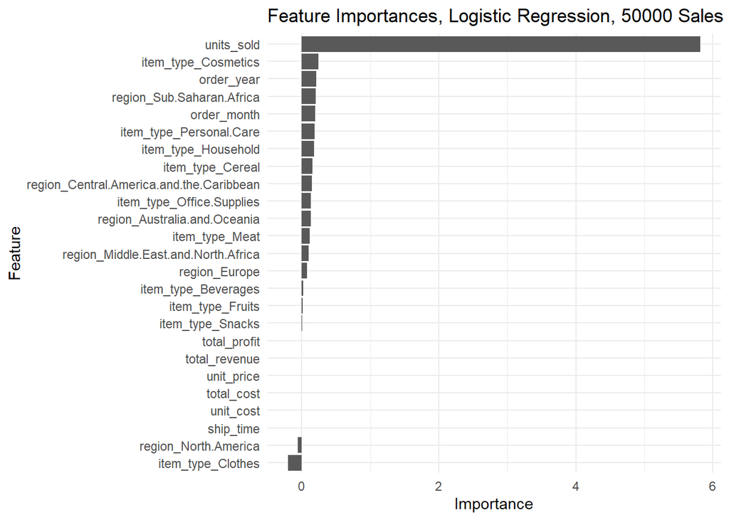

```r
# Get col names without target and coeff from model
feature_names <- colnames(trainSplit_large)
feature_names <- feature_names[ !feature_names == 'critical_priority']
coefficients <- log_model_large$coefficients

# Sort coeff in desc order
sort_coef <- order(abs(coefficients), decreasing = TRUE)

# Create the plot
ggplot(data.frame(Feature = feature_names[sort_coef], Coefficient = coefficients[sort_coef]), aes(x = Coefficient, y = reorder(Feature, Coefficient))) +
  geom_col() +
  labs(title = "Feature Importances, Logistic Regression, 50000 Sales", x = "Importance", y = "Feature") +
  theme_minimal()
```